[figure not shown]

# Principles of Data Science - Course Work

# Questions:

### What makes a MVP player different and what effect do they have on becoming a champion?

### Does playing position and style effect winning an MVP award and can we improve positions and playing style groups?

### Can we predict MVPs based on their performance?

#### Dataset 1 - Team Names:

Dataset 1 - Was fashioned by me to overcome the name changes I know that have occurred in the history of basketball franchises.

Team names were taken from:

(https://www.nba.com/teams)

Abbreviations were taken from:

(http://www.apbr.org/abbreviations.html)

```python
# Import Team Names dataset as dataframe and view table
names = pd.read_csv("Team_Names.csv")
names.head()
```

|  | team_name | abbs | other_abbs |
| --- | --- | --- | --- |
| 0 | Atlanta Hawks | ATL | MLH, STL, TOT, TRI |
| 1 | Brooklyn Nets | BKN | BRK, NYN, NJN |
| 2 | Boston Celtics | BOS | NaN |
| 3 | Charlotte Hornets | CHA | CHH |
| 4 | Chicago Bulls | CHI | NaN |

```python
# Check the data frame information and types
names.info()
```

```
<class 'pandas.core.frame.DataFrame'>
RangeIndex: 40 entries, 0 to 39
Data columns (total 3 columns):
 #   Column      Non-Null Count  Dtype
---  ------      --------------  -----
 0   team_name   40 non-null     object
 1   abbs        40 non-null     object
 2   other_abbs  15 non-null     object
dtypes: object(3)
memory usage: 1.1+ KB
```

```python
# Gather basic information about the dataset
print(f"Rows: {names.shape[0]}\nColumns: {names.shape[1]}")
```

```
Rows: 40
Columns: 3
```

```python
# Count number of null values in the dataset
names.isna().sum()
```

```
team_name      0
abbs           0
other_abbs    25
dtype: int64
```

As we can see 25 teams dont have any other abbreaviations or any previous names, leaving 15 teams that have had different names.

```python
# Lets take a look at all the unique team names
names.abbs.unique()
```

```
array(['ATL', 'BKN', 'BOS', 'CHA', 'CHI', 'CLE', 'DAL', 'DEN', 'DET',
       'GSW', 'HOU', 'IND', 'LAC', 'LAL', 'MEM', 'MIA', 'MIL', 'MIN',
       'NOP', 'NYK', 'OKC', 'ORL', 'PHI', 'PHX', 'POR', 'SAC', 'SAS',
       'TOR', 'UTA', 'WAS', 'FTW', 'INO', 'AND', 'WAT', 'CHO', 'SHE',
       'CHS', 'WSC', 'DNN', 'STB'], dtype=object)
```

```python
# Lets take a look at all the unique history team names
names.other_abbs.unique()
```

```
array(['MLH, STL, TOT, TRI', 'BRK, NYN, NJN', nan, 'CHH', 'PHW, SFW',
       'SDR', 'BUF, SDC', 'MNL', 'VAN', 'NOH, NOK', 'SEA', 'SYR', 'PHO',
       'KCK, KCO, CIN, ROC', 'NOJ', 'CAP, CHP, CHZ, WSB, BAL,BLB'],
      dtype=object)
```

#### Dataset 2 - Most Valuable Player Award:

This dataset was fashioned by me and taken from:

(http://www.espn.com/nba/history/awards/_/id/33)

```python
# Import MVP dataset as dataframe and view table
mvp = pd.read_csv("mvp_list.csv")
mvp.head()
```

|  | mvp_year | mvp_player | mvp_team |
| --- | --- | --- | --- |
| 0 | 2020 | Giannis Antetokounmpo | Milwaukee Bucks |
| 1 | 2019 | Giannis Antetokounmpo | Milwaukee Bucks |
| 2 | 2018 | James Harden | Houston Rockets |
| 3 | 2017 | Russell Westbrook | Oklahoma City Thunder |
| 4 | 2016 | Stephen Curry | Golden State Warriors |

```python
# Gather basic information about the dataset
print(f"Rows: {mvp.shape[0]}\nColumns: {mvp.shape[1]}")
```

```
Rows: 65
Columns: 3
```

```python
# Show the time period of the data
print (mvp.mvp_year.min())
print (mvp.mvp_year.max())
```

```
1956
2020
```

```python
# Check the data frame information and types
mvp.info()
```

```
<class 'pandas.core.frame.DataFrame'>
RangeIndex: 65 entries, 0 to 64
Data columns (total 3 columns):
 #   Column      Non-Null Count  Dtype
---  ------      --------------  -----
 0   mvp_year    65 non-null     int64
 1   mvp_player  65 non-null     object
 2   mvp_team    65 non-null     object
dtypes: int64(1), object(2)
memory usage: 1.6+ KB
```

```python
# Lets take a look at all the unique values
print("Number of players to have won the MVP award - ",mvp['mvp_player'].nunique())
# Lets take a look at all the unique values
print("The number of teams to have a player win the MVP award - ", mvp['mvp_team'].nunique())
```

```
Number of players to have won the MVP award -  34
The number of teams to have a player win the MVP award -  22
```

```python
# Group by player name to count how many MVPs won
most_mvps = mvp.groupby(['mvp_player'], as_index=False, sort=False)[["mvp_team"]].count()
# Sort the group by table
most_mvps = most_mvps.sort_values(by='mvp_team', ascending=False)
# Display table
most_mvps.head()
```

|  | mvp_player | mvp_team |
| --- | --- | --- |
| 23 | Kareem Abdul-Jabbar | 6 |
| 15 | Michael Jordan | 5 |
| 30 | Bill Russell | 5 |
| 5 | LeBron James | 4 |
| 29 | Wilt Chamberlain | 4 |

```python
# Group by Team name to count how many MVPs won
most_t_mvps = mvp.groupby(['mvp_team'], as_index=False, sort=False)[["mvp_player"]].count()
# Sort the group by table
most_t_mvps = most_t_mvps.sort_values(by='mvp_player', ascending=False)
# Display table
most_t_mvps.head()
```

|  | mvp_team | mvp_player |
| --- | --- | --- |
| 14 | Boston Celtics | 10 |
| 7 | Los Angeles Lakers | 8 |
| 12 | Philadelphia 76ers | 6 |
| 5 | Chicago Bulls | 6 |
| 0 | Milwaukee Bucks | 5 |

As we can see the player with most MVP awards is Kareem Abdul-Jabbar with 6 and the team with the most number of player to win the MVP award is Boston Celtics.

#### Dataset 3 - Championships:

This dataset was fashioned by me and taken from:

(https://en.wikipedia.org/wiki/List_of_NBA_champions)

```python
# Import Finals dataset as dataframe and view table
finals = pd.read_csv("finals.csv")
finals.head()
```

|  | final_team | final_year | final_won | final_lost |
| --- | --- | --- | --- | --- |
| 0 | Los Angeles Lakers | 1949 | 1 | 0 |
| 1 | Los Angeles Lakers | 1950 | 1 | 0 |
| 2 | Los Angeles Lakers | 1952 | 1 | 0 |
| 3 | Los Angeles Lakers | 1953 | 1 | 0 |
| 4 | Los Angeles Lakers | 1954 | 1 | 0 |

```python
# Gather basic information about the dataset
print(f"Rows: {finals.shape[0]}\nColumns: {finals.shape[1]}")
```

```
Rows: 148
Columns: 4
```

```python
# Check the data frame information and types
finals.info()
```

```
<class 'pandas.core.frame.DataFrame'>
RangeIndex: 148 entries, 0 to 147
Data columns (total 4 columns):
 #   Column      Non-Null Count  Dtype
---  ------      --------------  -----
 0   final_team  148 non-null    object
 1   final_year  148 non-null    int64
 2   final_won   148 non-null    int64
 3   final_lost  148 non-null    int64
dtypes: int64(3), object(1)
memory usage: 4.8+ KB
```

```python
# Lets take a look at all the unique value
print("Number of unique teams to reach finals - ",finals['final_team'].nunique())
```

```
Number of unique teams to reach finals -  27
```

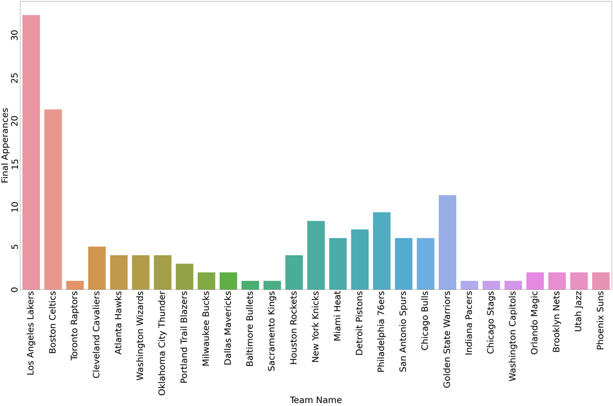

```python
# Visualise finalist frequency
fig1 = sns.countplot(x='final_team', data = finals)
fig1.figure.set_size_inches(60,30)
fig1.set_xlabel("Team Name", fontsize=50)
fig1.set_ylabel("Final Apperances", fontsize=50)
fig1.tick_params(labelsize = 50,rotation=90)
plt.show()
```

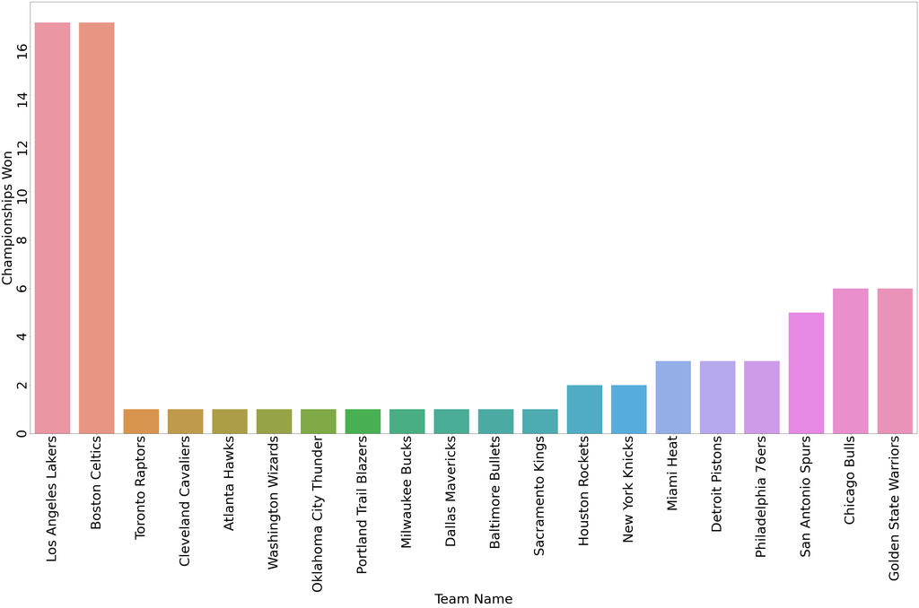

```python
# Visualise Number of Championships won
fig1 = sns.countplot(x='final_team', data = finals[finals['final_won'] > 0])
fig1.figure.set_size_inches(60,30)
fig1.set_xlabel("Team Name", fontsize=50)
fig1.set_ylabel("Championships Won", fontsize=50)
fig1.tick_params(labelsize = 50,rotation=90)
plt.show()
```

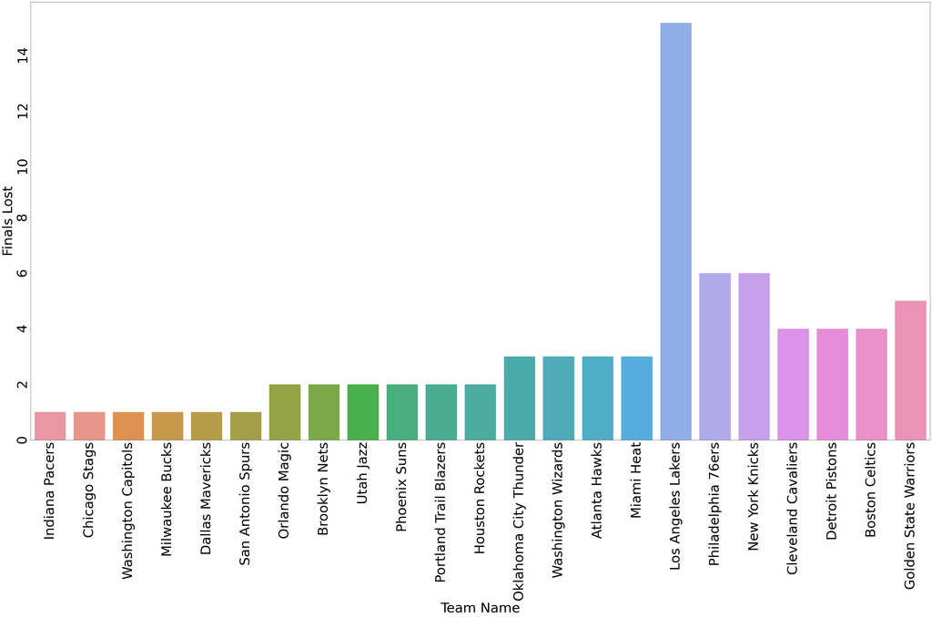

```python
# Visualise Number of Finals Lost
fig1 = sns.countplot(x='final_team', data = finals[finals['final_lost'] > 0])
fig1.figure.set_size_inches(60,30)
fig1.set_xlabel("Team Name", fontsize=50)
fig1.set_ylabel("Finals Lost", fontsize=50)
fig1.tick_params(labelsize = 50,rotation=90)
plt.show()
```

```python
# Group by Team name to sum won finals
gw_fins = finals.groupby(['final_team'], as_index=False, sort=False)[["final_won"]].sum()
# Sort the group by table
gw_fins = gw_fins.sort_values(by='final_won', ascending=False)
# Display table
gw_fins
```

|  | final_team | final_won |
| --- | --- | --- |
| 0 | Los Angeles Lakers | 17 |
| 1 | Boston Celtics | 17 |
| 19 | Golden State Warriors | 6 |
| 18 | Chicago Bulls | 6 |
| 17 | San Antonio Spurs | 5 |
| 16 | Philadelphia 76ers | 3 |
| 15 | Detroit Pistons | 3 |
| 14 | Miami Heat | 3 |
| 12 | Houston Rockets | 2 |
| 13 | New York Knicks | 2 |
| 10 | Baltimore Bullets | 1 |
| 5 | Washington Wizards | 1 |
| 2 | Toronto Raptors | 1 |
| 11 | Sacramento Kings | 1 |
| 4 | Atlanta Hawks | 1 |
| 3 | Cleveland Cavaliers | 1 |
| 6 | Oklahoma City Thunder | 1 |
| 7 | Portland Trail Blazers | 1 |
| 8 | Milwaukee Bucks | 1 |
| 9 | Dallas Mavericks | 1 |
| 20 | Indiana Pacers | 0 |
| 21 | Chicago Stags | 0 |
| 22 | Washington Capitols | 0 |
| 23 | Orlando Magic | 0 |
| 24 | Brooklyn Nets | 0 |
| 25 | Utah Jazz | 0 |
| 26 | Phoenix Suns | 0 |

Out of the 27 teams to reach the final 7 teams never won a championship. La Lakers and Bostin Celtics are tied at the top with the most championships at 17 each.

```python
# Group by Team name to sum lost finals
g_fins = finals.groupby(['final_team'], as_index=False, sort=False)[["final_lost"]].sum()
# Sort the group by table
g_fins = g_fins.sort_values(by='final_lost', ascending=False)
# Display table
g_fins
```

|  | final_team | final_lost |
| --- | --- | --- |
| 0 | Los Angeles Lakers | 15 |
| 16 | Philadelphia 76ers | 6 |
| 13 | New York Knicks | 6 |
| 19 | Golden State Warriors | 5 |
| 3 | Cleveland Cavaliers | 4 |
| 1 | Boston Celtics | 4 |
| 15 | Detroit Pistons | 4 |
| 4 | Atlanta Hawks | 3 |
| 5 | Washington Wizards | 3 |
| 6 | Oklahoma City Thunder | 3 |
| 14 | Miami Heat | 3 |
| 7 | Portland Trail Blazers | 2 |
| 25 | Utah Jazz | 2 |
| 24 | Brooklyn Nets | 2 |
| 23 | Orlando Magic | 2 |
| 26 | Phoenix Suns | 2 |
| 12 | Houston Rockets | 2 |
| 8 | Milwaukee Bucks | 1 |
| 20 | Indiana Pacers | 1 |
| 21 | Chicago Stags | 1 |
| 22 | Washington Capitols | 1 |
| 9 | Dallas Mavericks | 1 |
| 17 | San Antonio Spurs | 1 |
| 2 | Toronto Raptors | 0 |
| 18 | Chicago Bulls | 0 |
| 11 | Sacramento Kings | 0 |
| 10 | Baltimore Bullets | 0 |

Out of the 27 teams to reach the final only 4 teams have a 100% record of never losing a final. With LA Lakers losing the most finals with 15.

#### Dataset 4 - Player Stats:

This is the main dataset which was taken from Kaggle.com

(https://www.kaggle.com/drgilermo/nba-players-stats?select=Seasons_Stats.csv)

```python
# Import dataset as dataframe and view table
stats = pd.read_csv("Seasons_Stats.csv")
stats.head()
```

|  | Unnamed: 0 | Year | Player | Pos | Age | Tm | G | GS | MP | PER | ... | FT% | ORB | DRB | TRB | AST | STL | BLK | TOV | PF | PTS |
| --- | --- | --- | --- | --- | --- | --- | --- | --- | --- | --- | --- | --- | --- | --- | --- | --- | --- | --- | --- | --- | --- |
| 0 | 0 | 1950.0 | Curly Armstrong | G-F | 31.0 | FTW | 63.0 | NaN | NaN | NaN | ... | 0.705 | NaN | NaN | NaN | 176.0 | NaN | NaN | NaN | 217.0 | 458.0 |
| 1 | 1 | 1950.0 | Cliff Barker | SG | 29.0 | INO | 49.0 | NaN | NaN | NaN | ... | 0.708 | NaN | NaN | NaN | 109.0 | NaN | NaN | NaN | 99.0 | 279.0 |
| 2 | 2 | 1950.0 | Leo Barnhorst | SF | 25.0 | CHS | 67.0 | NaN | NaN | NaN | ... | 0.698 | NaN | NaN | NaN | 140.0 | NaN | NaN | NaN | 192.0 | 438.0 |
| 3 | 3 | 1950.0 | Ed Bartels | F | 24.0 | TOT | 15.0 | NaN | NaN | NaN | ... | 0.559 | NaN | NaN | NaN | 20.0 | NaN | NaN | NaN | 29.0 | 63.0 |
| 4 | 4 | 1950.0 | Ed Bartels | F | 24.0 | DNN | 13.0 | NaN | NaN | NaN | ... | 0.548 | NaN | NaN | NaN | 20.0 | NaN | NaN | NaN | 27.0 | 59.0 |

5 rows × 53 columns

```python
# Gather basic information about the dataset
print(f"Rows: {stats.shape[0]}\nColumns: {stats.shape[1]}")
```

```
Rows: 24691
Columns: 53
```

```python
# Show the time period of the data
print (stats.Year.min())
print (stats.Year.max())
```

```
1950.0
2017.0
```

```python
# Check the data frame information and types
stats.info()
```

```
<class 'pandas.core.frame.DataFrame'>
RangeIndex: 24691 entries, 0 to 24690
Data columns (total 53 columns):
 #   Column      Non-Null Count  Dtype
---  ------      --------------  -----
 0   Unnamed: 0  24691 non-null  int64
 1   Year        24624 non-null  float64
 2   Player      24624 non-null  object
 3   Pos         24624 non-null  object
 4   Age         24616 non-null  float64
 5   Tm          24624 non-null  object
 6   G           24624 non-null  float64
 7   GS          18233 non-null  float64
 8   MP          24138 non-null  float64
 9   PER         24101 non-null  float64
```

[output cut: 45 more lines]

```python
# Count number of null values in the dataset
stats.isna().sum()
```

```
Unnamed: 0        0
Year             67
Player           67
Pos              67
Age              75
Tm               67
G                67
GS             6458
MP              553
PER             590
TS%             153
3PAr           5852
FTr             166
ORB%           3899
DRB%           3899
TRB%           3120
AST%           2136
STL%           3899
BLK%           3899
TOV%           5109
USG%           5051
blanl         24691
OWS             106
DWS             106
WS              106
WS/48           590
blank2        24691
OBPM           3894
DBPM           3894
BPM            3894
VORP           3894
FG               67
FGA              67
FG%             166
3P             5764
3PA            5764
3P%            9275
2P               67
2PA              67
2P%             195
eFG%            166
FT               67
FTA              67
FT%             925
ORB            3894
DRB            3894
TRB             379
AST              67
STL            3894
BLK            3894
TOV            5046
PF               67
PTS              67
dtype: int64
```

As we can see the dataset has a significant amount of missing data that will need to be addressed.

```python
# Count number of null values in Team name column
stats['Tm'].nunique()
```

```
69
```

```python
# Lets take a look at all the unique team names
stats.Tm.unique()
```

```
array(['FTW', 'INO', 'CHS', 'TOT', 'DNN', 'NYK', 'TRI', 'AND', 'PHW',
       'WAT', 'SHE', 'ROC', 'BLB', 'MNL', 'SYR', 'WSC', 'BOS', 'STB', nan,
       'MLH', 'STL', 'DET', 'CIN', 'LAL', 'CHP', 'SFW', 'CHZ', 'BAL',
       'PHI', 'CHI', 'SDR', 'SEA', 'MIL', 'ATL', 'PHO', 'POR', 'CLE',
       'BUF', 'HOU', 'GSW', 'KCO', 'CAP', 'NOJ', 'WSB', 'KCK', 'IND',
       'NYN', 'DEN', 'SAS', 'NJN', 'SDC', 'UTA', 'DAL', 'LAC', 'SAC',
       'CHH', 'MIA', 'ORL', 'MIN', 'VAN', 'TOR', 'WAS', 'MEM', 'NOH',
       'CHA', 'NOK', 'OKC', 'BRK', 'NOP', 'CHO'], dtype=object)
```

As we can see we have 69 different unique team abbreaviations, but we know there is only 40 unique teams in the hisotry of the NBA. So we need to change some team names as they have changed through history.

```python
# Converting team abbreviations to latest team name
stats['Tm'] = stats['Tm'].replace(["MLH","STL","TOT","TRI"], "ATL")
stats['Tm'] = stats['Tm'].replace(["BRK","NYN","NJN"], "BKN")
stats['Tm'] = stats['Tm'].replace("CHH", "CHA")
stats['Tm'] = stats['Tm'].replace(["PHW","SFW"], "GSW")
stats['Tm'] = stats['Tm'].replace("SDR", "HOU")
stats['Tm'] = stats['Tm'].replace(["BUF","SDC"], "LAC")
stats['Tm'] = stats['Tm'].replace("MNL", "LAL")
stats['Tm'] = stats['Tm'].replace("VAN", "MEM")
stats['Tm'] = stats['Tm'].replace(["NOK","NOH"], "NOP")
stats['Tm'] = stats['Tm'].replace("SEA", "OKC")
stats['Tm'] = stats['Tm'].replace("SYR", "PHI")
stats['Tm'] = stats['Tm'].replace("PHO", "PHX")
stats['Tm'] = stats['Tm'].replace(["KCK","KCO","CIN","ROC"], "SAC")
stats['Tm'] = stats['Tm'].replace("NOJ", "UTA")
stats['Tm'] = stats['Tm'].replace(["CAP","CHP","CHZ","WSB","BAL","BLB"], "WAS")
```

```python
# Lets take a look at all the unique team names now
stats['Tm'].nunique()
```

```
40
```

Now team names are equal in each dataset and can join them on the correct ID later on.

Now lets take a look at the NaN values for Team name.

```python
# Check the rows with null values for team name
stats_check = stats[stats.Tm.isnull()]
stats_check.head()
```

|  | Unnamed: 0 | Year | Player | Pos | Age | Tm | G | GS | MP | PER | ... | FT% | ORB | DRB | TRB | AST | STL | BLK | TOV | PF | PTS |
| --- | --- | --- | --- | --- | --- | --- | --- | --- | --- | --- | --- | --- | --- | --- | --- | --- | --- | --- | --- | --- | --- |
| 312 | 312 | NaN | NaN | NaN | NaN | NaN | NaN | NaN | NaN | NaN | ... | NaN | NaN | NaN | NaN | NaN | NaN | NaN | NaN | NaN | NaN |
| 487 | 487 | NaN | NaN | NaN | NaN | NaN | NaN | NaN | NaN | NaN | ... | NaN | NaN | NaN | NaN | NaN | NaN | NaN | NaN | NaN | NaN |
| 618 | 618 | NaN | NaN | NaN | NaN | NaN | NaN | NaN | NaN | NaN | ... | NaN | NaN | NaN | NaN | NaN | NaN | NaN | NaN | NaN | NaN |
| 779 | 779 | NaN | NaN | NaN | NaN | NaN | NaN | NaN | NaN | NaN | ... | NaN | NaN | NaN | NaN | NaN | NaN | NaN | NaN | NaN | NaN |
| 911 | 911 | NaN | NaN | NaN | NaN | NaN | NaN | NaN | NaN | NaN | ... | NaN | NaN | NaN | NaN | NaN | NaN | NaN | NaN | NaN | NaN |

5 rows × 53 columns

These seem to be blank rows across the table so we can go ahead and just remove them alongside the blank columns.

```python
# Remove these null rows from the dataset
stats= stats[stats.Tm.notnull()]
stats = stats.drop(["blanl","blank2"],axis=1)
```

```python
# Lets rename the TM to abbs short for team abbreviation
stats = stats.rename(columns={'Tm': 'abbs'}, index={5: 5})
```

Now we can merge our first dataframes together.

```python
# Merge two tables created to form a new dataframe
stats2 = pd.merge(stats,names, on=['abbs'], how='inner')
```

```python
# Drop unwanted column
stats2 = stats2.drop(["other_abbs"],axis=1)
stats2.head()
```

|  | Unnamed: 0 | Year | Player | Pos | Age | abbs | G | GS | MP | PER | ... | ORB | DRB | TRB | AST | STL | BLK | TOV | PF | PTS | team_name |
| --- | --- | --- | --- | --- | --- | --- | --- | --- | --- | --- | --- | --- | --- | --- | --- | --- | --- | --- | --- | --- | --- |
| 0 | 0 | 1950.0 | Curly Armstrong | G-F | 31.0 | FTW | 63.0 | NaN | NaN | NaN | ... | NaN | NaN | NaN | 176.0 | NaN | NaN | NaN | 217.0 | 458.0 | Fort Worth Flyers |
| 1 | 9 | 1950.0 | Charlie Black | F-C | 28.0 | FTW | 36.0 | NaN | NaN | NaN | ... | NaN | NaN | NaN | 75.0 | NaN | NaN | NaN | 140.0 | 382.0 | Fort Worth Flyers |
| 2 | 28 | 1950.0 | Bob Carpenter | F-C | 32.0 | FTW | 66.0 | NaN | NaN | NaN | ... | NaN | NaN | NaN | 92.0 | NaN | NaN | NaN | 168.0 | 614.0 | Fort Worth Flyers |
| 3 | 94 | 1950.0 | Bob Harris | F-C | 22.0 | FTW | 62.0 | NaN | NaN | NaN | ... | NaN | NaN | NaN | 129.0 | NaN | NaN | NaN | 190.0 | 476.0 | Fort Worth Flyers |
| 4 | 101 | 1950.0 | Bill Henry | C | 25.0 | FTW | 44.0 | NaN | NaN | NaN | ... | NaN | NaN | NaN | 39.0 | NaN | NaN | NaN | 99.0 | 214.0 | Fort Worth Flyers |

5 rows × 52 columns

```python
# Check if we have any null values created after the merge
stats2['team_name'].isnull().sum()
```

```
0
```

Above the merge allowed us to bring in the full team name joining on the team abbreviation. Tracking the team names through history to its current name means with this join we can see the history of the team through the years and the players who have played for them.

And with 0 null values for the column bought in (team names) this means the join was successful.

```python
# Gather basic information about the dataset again
print(f"Rows: {stats2.shape[0]}\nColumns: {stats2.shape[1]}")
```

```
Rows: 24624
Columns: 52
```

Now let’s look at one of my all-time favourite players Kareem Abdul-Jabbar to see if the data is correct.

```python
# Create a mini filtered dataset to one name
KAJ = stats2[stats2.Player == 'Kareem Abdul-Jabbar']
KAJ.head()
```

|  | Unnamed: 0 | Year | Player | Pos | Age | abbs | G | GS | MP | PER | ... | ORB | DRB | TRB | AST | STL | BLK | TOV | PF | PTS | team_name |
| --- | --- | --- | --- | --- | --- | --- | --- | --- | --- | --- | --- | --- | --- | --- | --- | --- | --- | --- | --- | --- | --- |

0 rows × 52 columns

There seems to be an issue as no data has been returned. Lets filter to the team he played for LA Lakers and the year.

```python
LAL = stats2[(stats2.abbs == 'LAL') & (stats2.Year == 1976)]
LAL.head()
```

|  | Unnamed: 0 | Year | Player | Pos | Age | abbs | G | GS | MP | PER | ... | ORB | DRB | TRB | AST | STL | BLK | TOV | PF | PTS | team_name |
| --- | --- | --- | --- | --- | --- | --- | --- | --- | --- | --- | --- | --- | --- | --- | --- | --- | --- | --- | --- | --- | --- |
| 7838 | 4375 | 1976.0 | Kareem Abdul-Jabbar* | C | 28.0 | LAL | 82.0 | NaN | 3379.0 | 27.2 | ... | 272.0 | 1111.0 | 1383.0 | 413.0 | 119.0 | 338.0 | NaN | 292.0 | 2275.0 | Los Angeles Lakers |
| 7839 | 4378 | 1976.0 | Lucius Allen | PG | 28.0 | LAL | 76.0 | NaN | 2388.0 | 15.1 | ... | 64.0 | 150.0 | 214.0 | 357.0 | 101.0 | 20.0 | NaN | 241.0 | 1119.0 | Los Angeles Lakers |
| 7840 | 4415 | 1976.0 | Corky Calhoun | SF | 25.0 | LAL | 76.0 | NaN | 1816.0 | 9.0 | ... | 117.0 | 224.0 | 341.0 | 85.0 | 62.0 | 35.0 | NaN | 216.0 | 409.0 | Los Angeles Lakers |
| 7841 | 4453 | 1976.0 | Don Ford | SF | 23.0 | LAL | 76.0 | NaN | 1838.0 | 11.6 | ... | 118.0 | 215.0 | 333.0 | 111.0 | 50.0 | 14.0 | NaN | 186.0 | 726.0 | Los Angeles Lakers |
| 7842 | 4457 | 1976.0 | Donnie Freeman | SG | 31.0 | LAL | 64.0 | NaN | 1480.0 | 14.5 | ... | 72.0 | 108.0 | 180.0 | 171.0 | 57.0 | 11.0 | NaN | 160.0 | 689.0 | Los Angeles Lakers |

5 rows × 52 columns

As we can see there seems to be a "*" at the end of the name which is resulting in the no data return. This needs to be removed.

```python
# Replacing characters not needed in name column
stats2['Player'] = stats2['Player'].str.replace('*','')
KAJ2 = stats2[stats2.Player == 'Kareem Abdul-Jabbar']
KAJ2.head()
```

|  | Unnamed: 0 | Year | Player | Pos | Age | abbs | G | GS | MP | PER | ... | ORB | DRB | TRB | AST | STL | BLK | TOV | PF | PTS | team_name |
| --- | --- | --- | --- | --- | --- | --- | --- | --- | --- | --- | --- | --- | --- | --- | --- | --- | --- | --- | --- | --- | --- |
| 7838 | 4375 | 1976.0 | Kareem Abdul-Jabbar | C | 28.0 | LAL | 82.0 | NaN | 3379.0 | 27.2 | ... | 272.0 | 1111.0 | 1383.0 | 413.0 | 119.0 | 338.0 | NaN | 292.0 | 2275.0 | Los Angeles Lakers |
| 7855 | 4650 | 1977.0 | Kareem Abdul-Jabbar | C | 29.0 | LAL | 82.0 | NaN | 3016.0 | 27.8 | ... | 266.0 | 824.0 | 1090.0 | 319.0 | 101.0 | 261.0 | NaN | 262.0 | 2152.0 | Los Angeles Lakers |
| 7870 | 5010 | 1978.0 | Kareem Abdul-Jabbar | C | 30.0 | LAL | 62.0 | NaN | 2265.0 | 29.2 | ... | 186.0 | 615.0 | 801.0 | 269.0 | 103.0 | 185.0 | 208.0 | 182.0 | 1600.0 | Los Angeles Lakers |
| 7886 | 5382 | 1979.0 | Kareem Abdul-Jabbar | C | 31.0 | LAL | 80.0 | NaN | 3157.0 | 25.5 | ... | 207.0 | 818.0 | 1025.0 | 431.0 | 76.0 | 316.0 | 282.0 | 230.0 | 1903.0 | Los Angeles Lakers |
| 7899 | 5727 | 1980.0 | Kareem Abdul-Jabbar | C | 32.0 | LAL | 82.0 | NaN | 3143.0 | 25.3 | ... | 190.0 | 696.0 | 886.0 | 371.0 | 81.0 | 280.0 | 297.0 | 216.0 | 2034.0 | Los Angeles Lakers |

5 rows × 52 columns

Now we can merge our second dataframe to our main one.

```python
# Merge two tables created to form a new dataframe
stats3 = pd.merge(stats2,mvp, left_on=['Year','Player'], right_on=['mvp_year','mvp_player'], how='left')
stats3.head()
```

|  | Unnamed: 0 | Year | Player | Pos | Age | abbs | G | GS | MP | PER | ... | AST | STL | BLK | TOV | PF | PTS | team_name | mvp_year | mvp_player | mvp_team |
| --- | --- | --- | --- | --- | --- | --- | --- | --- | --- | --- | --- | --- | --- | --- | --- | --- | --- | --- | --- | --- | --- |
| 0 | 0 | 1950.0 | Curly Armstrong | G-F | 31.0 | FTW | 63.0 | NaN | NaN | NaN | ... | 176.0 | NaN | NaN | NaN | 217.0 | 458.0 | Fort Worth Flyers | NaN | NaN | NaN |
| 1 | 9 | 1950.0 | Charlie Black | F-C | 28.0 | FTW | 36.0 | NaN | NaN | NaN | ... | 75.0 | NaN | NaN | NaN | 140.0 | 382.0 | Fort Worth Flyers | NaN | NaN | NaN |
| 2 | 28 | 1950.0 | Bob Carpenter | F-C | 32.0 | FTW | 66.0 | NaN | NaN | NaN | ... | 92.0 | NaN | NaN | NaN | 168.0 | 614.0 | Fort Worth Flyers | NaN | NaN | NaN |
| 3 | 94 | 1950.0 | Bob Harris | F-C | 22.0 | FTW | 62.0 | NaN | NaN | NaN | ... | 129.0 | NaN | NaN | NaN | 190.0 | 476.0 | Fort Worth Flyers | NaN | NaN | NaN |
| 4 | 101 | 1950.0 | Bill Henry | C | 25.0 | FTW | 44.0 | NaN | NaN | NaN | ... | 39.0 | NaN | NaN | NaN | 99.0 | 214.0 | Fort Worth Flyers | NaN | NaN | NaN |

5 rows × 55 columns

```python
# Check the number of non null values after the merge
stats3['mvp_player'].notnull().sum()
```

```
60
```

```python
# Group by player name to count how many MVPs won
mm = stats3.groupby(['mvp_player'], as_index=False, sort=False)[["mvp_team"]].count()
# Sort the group by table
mm = mm.sort_values(by='mvp_team', ascending=False)
# Display table
mm
```

|  | mvp_player | mvp_team |
| --- | --- | --- |
| 5 | Kareem Abdul-Jabbar | 6 |
| 15 | Michael Jordan | 5 |
| 13 | Bill Russell | 5 |
| 2 | Wilt Chamberlain | 4 |
| 23 | LeBron James | 4 |
| 6 | Magic Johnson | 3 |
| 14 | Larry Bird | 3 |
| 10 | Moses Malone | 3 |
| 27 | Tim Duncan | 2 |
| 25 | Karl Malone | 2 |
| 21 | Steve Nash | 2 |
| 0 | Bob Pettit | 2 |
| 3 | Stephen Curry | 2 |
| 12 | Bob Cousy | 1 |
| 11 | Allen Iverson | 1 |
| 28 | Dirk Nowitzki | 1 |
| 26 | David Robinson | 1 |
| 4 | Oscar Robertson | 1 |
| 24 | Bob McAdoo | 1 |
| 7 | Shaquille O'Neal | 1 |
| 22 | Bill Walton | 1 |
| 8 | Kobe Bryant | 1 |
| 20 | Charles Barkley | 1 |
| 19 | Russell Westbrook | 1 |
| 18 | Kevin Durant | 1 |
| 17 | Hakeem Olajuwon | 1 |
| 16 | Derrick Rose | 1 |
| 1 | Willis Reed | 1 |
| 9 | Julius Erving | 1 |
| 29 | Kevin Garnett | 1 |

It seems with the join we have lost MVP players Giannis Antetokounmpo (2019,2020) & James Harden (2018) as our Stats dataset doesnt go past 2017.

We alos lost MVPs David Cowens & Westley Unseld as their data isnt in our stats data.

Now lets change the MVP columns to one that is binary as this is one of the assumptions for Logistic Regression which we will be using later.

```python
# Create column counting the characters
stats3['mvp']= stats3['mvp_player'].str.len()
```

```python
# Filter dataframe to new column
mvp_test = stats3[stats3.mvp > 0]
mvp_test.head()
```

|  | Unnamed: 0 | Year | Player | Pos | Age | abbs | G | GS | MP | PER | ... | STL | BLK | TOV | PF | PTS | team_name | mvp_year | mvp_player | mvp_team | mvp |
| --- | --- | --- | --- | --- | --- | --- | --- | --- | --- | --- | --- | --- | --- | --- | --- | --- | --- | --- | --- | --- | --- |
| 414 | 1095 | 1956.0 | Bob Pettit | C | 23.0 | ATL | 72.0 | NaN | 2794.0 | 27.3 | ... | NaN | NaN | NaN | 202.0 | 1849.0 | Atlanta Hawks | 1956.0 | Bob Pettit | St. Louis Hawks | 10.0 |
| 475 | 1428 | 1959.0 | Bob Pettit | PF | 26.0 | ATL | 72.0 | NaN | 2873.0 | 28.2 | ... | NaN | NaN | NaN | 200.0 | 2105.0 | Atlanta Hawks | 1959.0 | Bob Pettit | St. Louis Hawks | 10.0 |
| 3672 | 3008 | 1970.0 | Willis Reed | C | 27.0 | NYK | 81.0 | NaN | 3089.0 | 20.3 | ... | NaN | NaN | NaN | 287.0 | 1755.0 | New York Knicks | 1970.0 | Willis Reed | New York Knicks | 11.0 |
| 4574 | 1473 | 1960.0 | Wilt Chamberlain | C | 23.0 | GSW | 72.0 | NaN | 3338.0 | 28.0 | ... | NaN | NaN | NaN | 150.0 | 2707.0 | Golden State Warriors | 1960.0 | Wilt Chamberlain | Philadelphia Warriors | 16.0 |
| 5438 | 23000 | 2015.0 | Stephen Curry | PG | 26.0 | GSW | 80.0 | 80.0 | 2613.0 | 28.0 | ... | 163.0 | 16.0 | 249.0 | 158.0 | 1900.0 | Golden State Warriors | 2015.0 | Stephen Curry | Golden State Warriors | 13.0 |

5 rows × 56 columns

```python
# Check the values that are not null once more
mvp_test['mvp'].notnull().sum()
```

```
60
```

```python
# Create calculated binary column for mvp
stats3['mvp']=[1 if x > 0 else 0 for x in stats3['mvp']]
```

```python
stats3['mvp'].value_counts()
```

```
0    24564
1       60
Name: mvp, dtype: int64
```

Binary equal to 1 is 60 counts as we wished for.

```python
# Drop unwanted column
stats3 = stats3.drop(["mvp_team","mvp_year","mvp_player"],axis=1)
stats3.head()
```

|  | Unnamed: 0 | Year | Player | Pos | Age | abbs | G | GS | MP | PER | ... | DRB | TRB | AST | STL | BLK | TOV | PF | PTS | team_name | mvp |
| --- | --- | --- | --- | --- | --- | --- | --- | --- | --- | --- | --- | --- | --- | --- | --- | --- | --- | --- | --- | --- | --- |
| 0 | 0 | 1950.0 | Curly Armstrong | G-F | 31.0 | FTW | 63.0 | NaN | NaN | NaN | ... | NaN | NaN | 176.0 | NaN | NaN | NaN | 217.0 | 458.0 | Fort Worth Flyers | 0 |
| 1 | 9 | 1950.0 | Charlie Black | F-C | 28.0 | FTW | 36.0 | NaN | NaN | NaN | ... | NaN | NaN | 75.0 | NaN | NaN | NaN | 140.0 | 382.0 | Fort Worth Flyers | 0 |
| 2 | 28 | 1950.0 | Bob Carpenter | F-C | 32.0 | FTW | 66.0 | NaN | NaN | NaN | ... | NaN | NaN | 92.0 | NaN | NaN | NaN | 168.0 | 614.0 | Fort Worth Flyers | 0 |
| 3 | 94 | 1950.0 | Bob Harris | F-C | 22.0 | FTW | 62.0 | NaN | NaN | NaN | ... | NaN | NaN | 129.0 | NaN | NaN | NaN | 190.0 | 476.0 | Fort Worth Flyers | 0 |
| 4 | 101 | 1950.0 | Bill Henry | C | 25.0 | FTW | 44.0 | NaN | NaN | NaN | ... | NaN | NaN | 39.0 | NaN | NaN | NaN | 99.0 | 214.0 | Fort Worth Flyers | 0 |

5 rows × 53 columns

Now we have successfully joined the team name and mvp winners to the stats dataframe, now we need to add the finals dataframe.

```python
# Merge two tables created to form a new dataframe
stats4 = pd.merge(stats3,finals, left_on=['Year','team_name'], right_on=['final_year','final_team'], how='left')
stats4.head()
```

|  | Unnamed: 0 | Year | Player | Pos | Age | abbs | G | GS | MP | PER | ... | BLK | TOV | PF | PTS | team_name | mvp | final_team | final_year | final_won | final_lost |
| --- | --- | --- | --- | --- | --- | --- | --- | --- | --- | --- | --- | --- | --- | --- | --- | --- | --- | --- | --- | --- | --- |
| 0 | 0 | 1950.0 | Curly Armstrong | G-F | 31.0 | FTW | 63.0 | NaN | NaN | NaN | ... | NaN | NaN | 217.0 | 458.0 | Fort Worth Flyers | 0 | NaN | NaN | NaN | NaN |
| 1 | 9 | 1950.0 | Charlie Black | F-C | 28.0 | FTW | 36.0 | NaN | NaN | NaN | ... | NaN | NaN | 140.0 | 382.0 | Fort Worth Flyers | 0 | NaN | NaN | NaN | NaN |
| 2 | 28 | 1950.0 | Bob Carpenter | F-C | 32.0 | FTW | 66.0 | NaN | NaN | NaN | ... | NaN | NaN | 168.0 | 614.0 | Fort Worth Flyers | 0 | NaN | NaN | NaN | NaN |
| 3 | 94 | 1950.0 | Bob Harris | F-C | 22.0 | FTW | 62.0 | NaN | NaN | NaN | ... | NaN | NaN | 190.0 | 476.0 | Fort Worth Flyers | 0 | NaN | NaN | NaN | NaN |
| 4 | 101 | 1950.0 | Bill Henry | C | 25.0 | FTW | 44.0 | NaN | NaN | NaN | ... | NaN | NaN | 99.0 | 214.0 | Fort Worth Flyers | 0 | NaN | NaN | NaN | NaN |

5 rows × 57 columns

```python
# Gather basic information about the dataset
print(f"Rows: {stats4.shape[0]}\nColumns: {stats4.shape[1]}")
```

```
Rows: 24624
Columns: 57
```

```python
stats4['final_year'].notnull().sum()
```

```
1926
```

```python
# Check squad number in early years
sn = stats4[(stats4.abbs == 'LAL')]
# Group by player name to count how many MVPs won
sn = sn.groupby(['Year'], as_index=False, sort=False)[["Player"]].count()
# Sort the group by table
sn = sn.sort_values(by='Year', ascending=False)
# Display table
sn
```

|  | Year | Player |
| --- | --- | --- |
| 67 | 2017.0 | 18 |
| 66 | 2016.0 | 15 |
| 65 | 2015.0 | 18 |
| 64 | 2014.0 | 19 |
| 63 | 2013.0 | 16 |
| ... | ... | ... |
| 4 | 1954.0 | 11 |
| 3 | 1953.0 | 10 |
| 2 | 1952.0 | 10 |
| 1 | 1951.0 | 11 |
| 0 | 1950.0 | 14 |

68 rows × 2 columns

After the merge the teams that reached the final before 1950 and after 2017 would be dropped from the dataframe, theoratically leaving 136 rows to be joined to stats dataframe, given this will replicate for each player in a team for that given year the value 136 should be multiplied by the squad number which is 15. Which should give us 2040, but we have 1926 but from the table above 'sn' we can see that squad numbers changed from year to year.

As we can some seasons the count of players have gone over the limit of 15 players. After some research I found out that players can transfer mid season wich means they can have duplicate rows. Lets remove these.

```python
# Filter dataframe to a year
dup = stats4[(stats4.Year == 2017)]
dup.head(50)
```

|  | Unnamed: 0 | Year | Player | Pos | Age | abbs | G | GS | MP | PER | ... | BLK | TOV | PF | PTS | team_name | mvp | final_team | final_year | final_won | final_lost |
| --- | --- | --- | --- | --- | --- | --- | --- | --- | --- | --- | --- | --- | --- | --- | --- | --- | --- | --- | --- | --- | --- |
| 3295 | 24097 | 2017.0 | Quincy Acy | PF | 26.0 | ATL | 38.0 | 1.0 | 558.0 | 11.8 | ... | 15.0 | 21.0 | 67.0 | 222.0 | Atlanta Hawks | 0 | NaN | NaN | NaN | NaN |
| 3296 | 24110 | 2017.0 | Justin Anderson | SF | 23.0 | ATL | 75.0 | 10.0 | 1228.0 | 13.9 | ... | 23.0 | 66.0 | 109.0 | 532.0 | Atlanta Hawks | 0 | NaN | NaN | NaN | NaN |
| 3297 | 24128 | 2017.0 | Matt Barnes | SF | 36.0 | ATL | 74.0 | 18.0 | 1777.0 | 10.3 | ... | 26.0 | 107.0 | 185.0 | 527.0 | Atlanta Hawks | 0 | NaN | NaN | NaN | NaN |
| 3298 | 24136 | 2017.0 | Kent Bazemore | SF | 27.0 | ATL | 73.0 | 64.0 | 1963.0 | 11.5 | ... | 52.0 | 125.0 | 165.0 | 801.0 | Atlanta Hawks | 0 | NaN | NaN | NaN | NaN |
| 3299 | 24141 | 2017.0 | DeAndre' Bembry | SF | 22.0 | ATL | 38.0 | 1.0 | 371.0 | 8.8 | ... | 5.0 | 16.0 | 21.0 | 101.0 | Atlanta Hawks | 0 | NaN | NaN | NaN | NaN |
| 3300 | 24151 | 2017.0 | Bojan Bogdanovic | SF | 27.0 | ATL | 81.0 | 54.0 | 2083.0 | 13.5 | ... | 7.0 | 130.0 | 146.0 | 1113.0 | Atlanta Hawks | 0 | NaN | NaN | NaN | NaN |
| 3301 | 24154 | 2017.0 | Andrew Bogut | C | 32.0 | ATL | 27.0 | 21.0 | 583.0 | 9.3 | ... | 25.0 | 43.0 | 86.0 | 79.0 | Atlanta Hawks | 0 | NaN | NaN | NaN | NaN |
| 3302 | 24161 | 2017.0 | Corey Brewer | SF | 30.0 | ATL | 82.0 | 11.0 | 1281.0 | 9.1 | ... | 19.0 | 55.0 | 133.0 | 371.0 | Atlanta Hawks | 0 | NaN | NaN | NaN | NaN |
| 3303 | 24166 | 2017.0 | Anthony Brown | SF | 24.0 | ATL | 11.0 | 0.0 | 159.0 | 7.2 | ... | 1.0 | 6.0 | 15.0 | 43.0 | Atlanta Hawks | 0 | NaN | NaN | NaN | NaN |
| 3304 | 24177 | 2017.0 | Jose Calderon | PG | 35.0 | ATL | 41.0 | 13.0 | 539.0 | 8.9 | ... | 1.0 | 41.0 | 36.0 | 141.0 | Atlanta Hawks | 0 | NaN | NaN | NaN | NaN |
| 3305 | 24179 | 2017.0 | Jose Calderon | PG | 35.0 | ATL | 17.0 | 2.0 | 247.0 | 8.7 | ... | 0.0 | 15.0 | 14.0 | 61.0 | Atlanta Hawks | 0 | NaN | NaN | NaN | NaN |
| 3306 | 24186 | 2017.0 | Omri Casspi | SF | 28.0 | ATL | 36.0 | 2.0 | 643.0 | 9.9 | ... | 3.0 | 29.0 | 50.0 | 186.0 | Atlanta Hawks | 0 | NaN | NaN | NaN | NaN |
| 3307 | 24203 | 2017.0 | Quinn Cook | PG | 23.0 | ATL | 14.0 | 0.0 | 188.0 | 11.8 | ... | 0.0 | 13.0 | 13.0 | 79.0 | Atlanta Hawks | 0 | NaN | NaN | NaN | NaN |
| 3308 | 24206 | 2017.0 | DeMarcus Cousins | C | 26.0 | ATL | 72.0 | 72.0 | 2465.0 | 25.7 | ... | 92.0 | 269.0 | 278.0 | 1942.0 | Atlanta Hawks | 0 | NaN | NaN | NaN | NaN |
| 3309 | 24223 | 2017.0 | Malcolm Delaney | PG | 27.0 | ATL | 73.0 | 2.0 | 1248.0 | 7.5 | ... | 1.0 | 95.0 | 112.0 | 391.0 | Atlanta Hawks | 0 | NaN | NaN | NaN | NaN |
| 3310 | 24235 | 2017.0 | Mike Dunleavy | SF | 36.0 | ATL | 53.0 | 2.0 | 841.0 | 10.1 | ... | 7.0 | 28.0 | 67.0 | 275.0 | Atlanta Hawks | 0 | NaN | NaN | NaN | NaN |
| 3311 | 24237 | 2017.0 | Mike Dunleavy | SF | 36.0 | ATL | 30.0 | 0.0 | 475.0 | 11.9 | ... | 5.0 | 14.0 | 35.0 | 169.0 | Atlanta Hawks | 0 | NaN | NaN | NaN | NaN |
| 3312 | 24246 | 2017.0 | Tyler Ennis | PG | 22.0 | ATL | 53.0 | 2.0 | 588.0 | 11.0 | ... | 2.0 | 45.0 | 58.0 | 228.0 | Atlanta Hawks | 0 | NaN | NaN | NaN | NaN |
| 3313 | 24249 | 2017.0 | Tyreke Evans | SF | 27.0 | ATL | 40.0 | 6.0 | 788.0 | 15.5 | ... | 9.0 | 61.0 | 60.0 | 411.0 | Atlanta Hawks | 0 | NaN | NaN | NaN | NaN |
| 3314 | 24259 | 2017.0 | Yogi Ferrell | PG | 23.0 | ATL | 46.0 | 29.0 | 1197.0 | 13.1 | ... | 9.0 | 70.0 | 90.0 | 462.0 | Atlanta Hawks | 0 | NaN | NaN | NaN | NaN |
| 3315 | 24269 | 2017.0 | Langston Galloway | PG | 25.0 | ATL | 74.0 | 2.0 | 1495.0 | 10.4 | ... | 6.0 | 46.0 | 96.0 | 585.0 | Atlanta Hawks | 0 | NaN | NaN | NaN | NaN |
| 3316 | 24281 | 2017.0 | Taj Gibson | PF | 31.0 | ATL | 78.0 | 71.0 | 1989.0 | 15.1 | ... | 66.0 | 105.0 | 163.0 | 846.0 | Atlanta Hawks | 0 | NaN | NaN | NaN | NaN |
| 3317 | 24286 | 2017.0 | Archie Goodwin | SG | 22.0 | ATL | 15.0 | 0.0 | 214.0 | 18.7 | ... | 5.0 | 14.0 | 8.0 | 110.0 | Atlanta Hawks | 0 | NaN | NaN | NaN | NaN |
| 3318 | 24293 | 2017.0 | Jerami Grant | SF | 22.0 | ATL | 80.0 | 4.0 | 1531.0 | 10.1 | ... | 79.0 | 44.0 | 149.0 | 437.0 | Atlanta Hawks | 0 | NaN | NaN | NaN | NaN |
| 3319 | 24305 | 2017.0 | Tim Hardaway | SG | 24.0 | ATL | 79.0 | 30.0 | 2154.0 | 15.2 | ... | 15.0 | 106.0 | 103.0 | 1143.0 | Atlanta Hawks | 0 | NaN | NaN | NaN | NaN |
| 3320 | 24318 | 2017.0 | Spencer Hawes | PF | 28.0 | ATL | 54.0 | 1.0 | 797.0 | 15.6 | ... | 30.0 | 49.0 | 77.0 | 337.0 | Atlanta Hawks | 0 | NaN | NaN | NaN | NaN |
| 3321 | 24327 | 2017.0 | Roy Hibbert | C | 30.0 | ATL | 48.0 | 13.0 | 682.0 | 13.6 | ... | 46.0 | 32.0 | 100.0 | 221.0 | Atlanta Hawks | 0 | NaN | NaN | NaN | NaN |
| 3322 | 24330 | 2017.0 | Buddy Hield | SG | 23.0 | ATL | 82.0 | 55.0 | 1888.0 | 11.8 | ... | 9.0 | 101.0 | 115.0 | 866.0 | Atlanta Hawks | 0 | NaN | NaN | NaN | NaN |
| 3323 | 24345 | 2017.0 | Dwight Howard | C | 31.0 | ATL | 74.0 | 74.0 | 2199.0 | 20.8 | ... | 92.0 | 170.0 | 203.0 | 1002.0 | Atlanta Hawks | 0 | NaN | NaN | NaN | NaN |
| 3324 | 24348 | 2017.0 | Kris Humphries | PF | 31.0 | ATL | 56.0 | 4.0 | 689.0 | 13.6 | ... | 21.0 | 28.0 | 69.0 | 257.0 | Atlanta Hawks | 0 | NaN | NaN | NaN | NaN |
| 3325 | 24350 | 2017.0 | Serge Ibaka | PF | 27.0 | ATL | 79.0 | 79.0 | 2422.0 | 16.4 | ... | 124.0 | 105.0 | 215.0 | 1173.0 | Atlanta Hawks | 0 | NaN | NaN | NaN | NaN |
| 3326 | 24354 | 2017.0 | Ersan Ilyasova | PF | 29.0 | ATL | 82.0 | 52.0 | 2142.0 | 14.6 | ... | 23.0 | 116.0 | 211.0 | 1071.0 | Atlanta Hawks | 0 | NaN | NaN | NaN | NaN |
| 3327 | 24357 | 2017.0 | Ersan Ilyasova | PF | 29.0 | ATL | 26.0 | 12.0 | 633.0 | 13.5 | ... | 8.0 | 34.0 | 73.0 | 270.0 | Atlanta Hawks | 0 | NaN | NaN | NaN | NaN |
| 3328 | 24369 | 2017.0 | Brandon Jennings | PG | 27.0 | ATL | 81.0 | 13.0 | 1802.0 | 12.1 | ... | 5.0 | 128.0 | 116.0 | 577.0 | Atlanta Hawks | 0 | NaN | NaN | NaN | NaN |
| 3329 | 24385 | 2017.0 | Terrence Jones | PF | 25.0 | ATL | 54.0 | 12.0 | 1270.0 | 16.1 | ... | 54.0 | 48.0 | 67.0 | 584.0 | Atlanta Hawks | 0 | NaN | NaN | NaN | NaN |
| 3330 | 24393 | 2017.0 | Ryan Kelly | PF | 25.0 | ATL | 16.0 | 0.0 | 110.0 | 7.8 | ... | 5.0 | 4.0 | 5.0 | 25.0 | Atlanta Hawks | 0 | NaN | NaN | NaN | NaN |
| 3331 | 24397 | 2017.0 | Kyle Korver | SG | 35.0 | ATL | 67.0 | 22.0 | 1753.0 | 12.1 | ... | 21.0 | 69.0 | 107.0 | 678.0 | Atlanta Hawks | 0 | NaN | NaN | NaN | NaN |
| 3332 | 24398 | 2017.0 | Kyle Korver | SG | 35.0 | ATL | 32.0 | 21.0 | 894.0 | 10.9 | ... | 13.0 | 40.0 | 47.0 | 305.0 | Atlanta Hawks | 0 | NaN | NaN | NaN | NaN |
| 3333 | 24405 | 2017.0 | Joffrey Lauvergne | PF-C | 25.0 | ATL | 70.0 | 1.0 | 980.0 | 12.6 | ... | 6.0 | 56.0 | 83.0 | 375.0 | Atlanta Hawks | 0 | NaN | NaN | NaN | NaN |
| 3334 | 24418 | 2017.0 | DeAndre Liggins | SG | 28.0 | ATL | 62.0 | 19.0 | 777.0 | 7.5 | ... | 14.0 | 42.0 | 81.0 | 152.0 | Atlanta Hawks | 0 | NaN | NaN | NaN | NaN |
| 3335 | 24445 | 2017.0 | Chris McCullough | PF | 21.0 | ATL | 16.0 | 0.0 | 80.0 | 15.2 | ... | 2.0 | 3.0 | 7.0 | 36.0 | Atlanta Hawks | 0 | NaN | NaN | NaN | NaN |
| 3336 | 24448 | 2017.0 | K.J. McDaniels | SF | 23.0 | ATL | 49.0 | 0.0 | 505.0 | 11.5 | ... | 18.0 | 29.0 | 49.0 | 206.0 | Atlanta Hawks | 0 | NaN | NaN | NaN | NaN |
| 3337 | 24451 | 2017.0 | Doug McDermott | SF | 25.0 | ATL | 66.0 | 5.0 | 1508.0 | 10.7 | ... | 5.0 | 38.0 | 79.0 | 592.0 | Atlanta Hawks | 0 | NaN | NaN | NaN | NaN |
| 3338 | 24467 | 2017.0 | Paul Millsap | PF | 31.0 | ATL | 69.0 | 67.0 | 2343.0 | 17.8 | ... | 62.0 | 158.0 | 186.0 | 1246.0 | Atlanta Hawks | 0 | NaN | NaN | NaN | NaN |
| 3339 | 24473 | 2017.0 | Anthony Morrow | SG | 31.0 | ATL | 49.0 | 7.0 | 714.0 | 10.0 | ... | 2.0 | 6.0 | 44.0 | 271.0 | Atlanta Hawks | 0 | NaN | NaN | NaN | NaN |
| 3340 | 24482 | 2017.0 | Mike Muscala | C | 25.0 | ATL | 70.0 | 3.0 | 1237.0 | 14.4 | ... | 41.0 | 55.0 | 97.0 | 435.0 | Atlanta Hawks | 0 | NaN | NaN | NaN | NaN |
| 3341 | 24486 | 2017.0 | Gary Neal | SG | 32.0 | ATL | 2.0 | 0.0 | 18.0 | -4.3 | ... | 0.0 | 0.0 | 1.0 | 4.0 | Atlanta Hawks | 0 | NaN | NaN | NaN | NaN |
| 3342 | 24490 | 2017.0 | Andrew Nicholson | PF | 27.0 | ATL | 38.0 | 0.0 | 342.0 | 5.9 | ... | 6.0 | 17.0 | 55.0 | 100.0 | Atlanta Hawks | 0 | NaN | NaN | NaN | NaN |
| 3343 | 24494 | 2017.0 | Nerlens Noel | C | 22.0 | ATL | 51.0 | 19.0 | 1047.0 | 20.4 | ... | 51.0 | 51.0 | 126.0 | 445.0 | Atlanta Hawks | 0 | NaN | NaN | NaN | NaN |
| 3344 | 24500 | 2017.0 | Jusuf Nurkic | C | 22.0 | ATL | 65.0 | 48.0 | 1391.0 | 17.5 | ... | 74.0 | 143.0 | 161.0 | 662.0 | Atlanta Hawks | 0 | NaN | NaN | NaN | NaN |

50 rows × 57 columns

```python
# Filter dataframe again to duplicate name
dup = stats4[(stats4.Year == 2017) & (stats4.Player == "Jose Calderon")]
dup
```

|  | Unnamed: 0 | Year | Player | Pos | Age | abbs | G | GS | MP | PER | ... | BLK | TOV | PF | PTS | team_name | mvp | final_team | final_year | final_won | final_lost |
| --- | --- | --- | --- | --- | --- | --- | --- | --- | --- | --- | --- | --- | --- | --- | --- | --- | --- | --- | --- | --- | --- |
| 3304 | 24177 | 2017.0 | Jose Calderon | PG | 35.0 | ATL | 41.0 | 13.0 | 539.0 | 8.9 | ... | 1.0 | 41.0 | 36.0 | 141.0 | Atlanta Hawks | 0 | NaN | NaN | NaN | NaN |
| 3305 | 24179 | 2017.0 | Jose Calderon | PG | 35.0 | ATL | 17.0 | 2.0 | 247.0 | 8.7 | ... | 0.0 | 15.0 | 14.0 | 61.0 | Atlanta Hawks | 0 | NaN | NaN | NaN | NaN |
| 8465 | 24178 | 2017.0 | Jose Calderon | PG | 35.0 | LAL | 24.0 | 11.0 | 292.0 | 9.1 | ... | 1.0 | 26.0 | 22.0 | 80.0 | Los Angeles Lakers | 0 | NaN | NaN | NaN | NaN |

3 rows × 57 columns

```python
# Test removing duplicate on subset year, player
dup2 = dup.drop_duplicates(subset=['Year','Player'])
dup2
```

|  | Unnamed: 0 | Year | Player | Pos | Age | abbs | G | GS | MP | PER | ... | BLK | TOV | PF | PTS | team_name | mvp | final_team | final_year | final_won | final_lost |
| --- | --- | --- | --- | --- | --- | --- | --- | --- | --- | --- | --- | --- | --- | --- | --- | --- | --- | --- | --- | --- | --- |
| 3304 | 24177 | 2017.0 | Jose Calderon | PG | 35.0 | ATL | 41.0 | 13.0 | 539.0 | 8.9 | ... | 1.0 | 41.0 | 36.0 | 141.0 | Atlanta Hawks | 0 | NaN | NaN | NaN | NaN |

1 rows × 57 columns

Now we have one row for Jose with his totals, lets repeat for our main dataframe.

```python
# Remove duplicates using subset
stats4 = stats4.drop_duplicates(subset=['Year','Player'])
```

```python
# Filter dataframe to check our code
tester = stats4[stats4.Player == "Jose Calderon"]
tester.head()
```

|  | Unnamed: 0 | Year | Player | Pos | Age | abbs | G | GS | MP | PER | ... | BLK | TOV | PF | PTS | team_name | mvp | final_team | final_year | final_won | final_lost |
| --- | --- | --- | --- | --- | --- | --- | --- | --- | --- | --- | --- | --- | --- | --- | --- | --- | --- | --- | --- | --- | --- |
| 2994 | 21763 | 2013.0 | Jose Calderon | PG | 31.0 | ATL | 73.0 | 58.0 | 2160.0 | 18.8 | ... | 8.0 | 126.0 | 99.0 | 826.0 | Atlanta Hawks | 0 | NaN | NaN | NaN | NaN |
| 3304 | 24177 | 2017.0 | Jose Calderon | PG | 35.0 | ATL | 41.0 | 13.0 | 539.0 | 8.9 | ... | 1.0 | 41.0 | 36.0 | 141.0 | Atlanta Hawks | 0 | NaN | NaN | NaN | NaN |
| 4379 | 22958 | 2015.0 | Jose Calderon | PG | 33.0 | NYK | 42.0 | 42.0 | 1270.0 | 11.3 | ... | 0.0 | 75.0 | 76.0 | 382.0 | New York Knicks | 0 | NaN | NaN | NaN | NaN |
| 4398 | 23597 | 2016.0 | Jose Calderon | PG | 34.0 | NYK | 72.0 | 72.0 | 2024.0 | 12.3 | ... | 7.0 | 87.0 | 135.0 | 544.0 | New York Knicks | 0 | NaN | NaN | NaN | NaN |
| 21588 | 22364 | 2014.0 | Jose Calderon | PG | 32.0 | DAL | 81.0 | 81.0 | 2468.0 | 15.2 | ... | 11.0 | 103.0 | 136.0 | 925.0 | Dallas Mavericks | 0 | NaN | NaN | NaN | NaN |

5 rows × 57 columns

```python
# Drop unwanted column
stats5 = stats4.drop(["final_year","final_team"],axis=1)
stats5.head()
```

|  | Unnamed: 0 | Year | Player | Pos | Age | abbs | G | GS | MP | PER | ... | AST | STL | BLK | TOV | PF | PTS | team_name | mvp | final_won | final_lost |
| --- | --- | --- | --- | --- | --- | --- | --- | --- | --- | --- | --- | --- | --- | --- | --- | --- | --- | --- | --- | --- | --- |
| 0 | 0 | 1950.0 | Curly Armstrong | G-F | 31.0 | FTW | 63.0 | NaN | NaN | NaN | ... | 176.0 | NaN | NaN | NaN | 217.0 | 458.0 | Fort Worth Flyers | 0 | NaN | NaN |
| 1 | 9 | 1950.0 | Charlie Black | F-C | 28.0 | FTW | 36.0 | NaN | NaN | NaN | ... | 75.0 | NaN | NaN | NaN | 140.0 | 382.0 | Fort Worth Flyers | 0 | NaN | NaN |
| 2 | 28 | 1950.0 | Bob Carpenter | F-C | 32.0 | FTW | 66.0 | NaN | NaN | NaN | ... | 92.0 | NaN | NaN | NaN | 168.0 | 614.0 | Fort Worth Flyers | 0 | NaN | NaN |
| 3 | 94 | 1950.0 | Bob Harris | F-C | 22.0 | FTW | 62.0 | NaN | NaN | NaN | ... | 129.0 | NaN | NaN | NaN | 190.0 | 476.0 | Fort Worth Flyers | 0 | NaN | NaN |
| 4 | 101 | 1950.0 | Bill Henry | C | 25.0 | FTW | 44.0 | NaN | NaN | NaN | ... | 39.0 | NaN | NaN | NaN | 99.0 | 214.0 | Fort Worth Flyers | 0 | NaN | NaN |

5 rows × 55 columns

#### Dataset 5 - Player Details:

This is a sub dataset which was taken from Kaggle.com

(https://www.kaggle.com/drgilermo/nba-players-stats?select=Seasons_Stats.csv)

```python
# Import dataset as dataframe and view table
details = pd.read_csv("player_data.csv")
details.head()
```

|  | name | year_start | year_end | position | height | weight | birth_date | college |
| --- | --- | --- | --- | --- | --- | --- | --- | --- |
| 0 | Alaa Abdelnaby | 1991 | 1995 | F-C | 6-10 | 240.0 | June 24, 1968 | Duke University |
| 1 | Zaid Abdul-Aziz | 1969 | 1978 | C-F | 6-9 | 235.0 | April 7, 1946 | Iowa State University |
| 2 | Kareem Abdul-Jabbar | 1970 | 1989 | C | 7-2 | 225.0 | April 16, 1947 | University of California, Los Angeles |
| 3 | Mahmoud Abdul-Rauf | 1991 | 2001 | G | 6-1 | 162.0 | March 9, 1969 | Louisiana State University |
| 4 | Tariq Abdul-Wahad | 1998 | 2003 | F | 6-6 | 223.0 | November 3, 1974 | San Jose State University |

```python
# Merge two tables created to form a new dataframe
stats5 = pd.merge(stats5,details, left_on=['Player'], right_on=['name'], how='left')
stats5.head()
```

|  | Unnamed: 0 | Year | Player | Pos | Age | abbs | G | GS | MP | PER | ... | final_won | final_lost | name | year_start | year_end | position | height | weight | birth_date | college |
| --- | --- | --- | --- | --- | --- | --- | --- | --- | --- | --- | --- | --- | --- | --- | --- | --- | --- | --- | --- | --- | --- |
| 0 | 0 | 1950.0 | Curly Armstrong | G-F | 31.0 | FTW | 63.0 | NaN | NaN | NaN | ... | NaN | NaN | Curly Armstrong | 1949.0 | 1951.0 | G-F | 5-11 | 170.0 | November 1, 1918 | Indiana University |
| 1 | 9 | 1950.0 | Charlie Black | F-C | 28.0 | FTW | 36.0 | NaN | NaN | NaN | ... | NaN | NaN | Charlie Black | 1949.0 | 1952.0 | F-C | 6-5 | 200.0 | June 15, 1921 | University of Kansas |
| 2 | 28 | 1950.0 | Bob Carpenter | F-C | 32.0 | FTW | 66.0 | NaN | NaN | NaN | ... | NaN | NaN | Bob Carpenter | 1950.0 | 1951.0 | F-C | 6-5 | 200.0 | November 6, 1917 | East Texas State University |
| 3 | 94 | 1950.0 | Bob Harris | F-C | 22.0 | FTW | 62.0 | NaN | NaN | NaN | ... | NaN | NaN | Bob Harris | 1950.0 | 1954.0 | F-C | 6-7 | 195.0 | March 16, 1927 | Oklahoma State University |
| 4 | 101 | 1950.0 | Bill Henry | C | 25.0 | FTW | 44.0 | NaN | NaN | NaN | ... | NaN | NaN | Bill Henry | 1949.0 | 1950.0 | C | 6-9 | 215.0 | December 27, 1924 | Rice University |

5 rows × 63 columns

```python
# Drop unwanted column
stats5 = stats5.drop(["name","height","birth_date","position","Unnamed: 0","year_start","year_end"],axis=1)
stats5.head()
```

|  | Year | Player | Pos | Age | abbs | G | GS | MP | PER | TS% | ... | BLK | TOV | PF | PTS | team_name | mvp | final_won | final_lost | weight | college |
| --- | --- | --- | --- | --- | --- | --- | --- | --- | --- | --- | --- | --- | --- | --- | --- | --- | --- | --- | --- | --- | --- |
| 0 | 1950.0 | Curly Armstrong | G-F | 31.0 | FTW | 63.0 | NaN | NaN | NaN | 0.368 | ... | NaN | NaN | 217.0 | 458.0 | Fort Worth Flyers | 0 | NaN | NaN | 170.0 | Indiana University |
| 1 | 1950.0 | Charlie Black | F-C | 28.0 | FTW | 36.0 | NaN | NaN | NaN | 0.362 | ... | NaN | NaN | 140.0 | 382.0 | Fort Worth Flyers | 0 | NaN | NaN | 200.0 | University of Kansas |
| 2 | 1950.0 | Bob Carpenter | F-C | 32.0 | FTW | 66.0 | NaN | NaN | NaN | 0.421 | ... | NaN | NaN | 168.0 | 614.0 | Fort Worth Flyers | 0 | NaN | NaN | 200.0 | East Texas State University |
| 3 | 1950.0 | Bob Harris | F-C | 22.0 | FTW | 62.0 | NaN | NaN | NaN | 0.423 | ... | NaN | NaN | 190.0 | 476.0 | Fort Worth Flyers | 0 | NaN | NaN | 195.0 | Oklahoma State University |
| 4 | 1950.0 | Bill Henry | C | 25.0 | FTW | 44.0 | NaN | NaN | NaN | 0.405 | ... | NaN | NaN | 99.0 | 214.0 | Fort Worth Flyers | 0 | NaN | NaN | 215.0 | Rice University |

5 rows × 56 columns

#### Dataset 6 - Player Details 2:

This is a sub dataset which was taken from Kaggle.com

(https://www.kaggle.com/drgilermo/nba-players-stats?select=Seasons_Stats.csv)

```python
# Import dataset as dataframe and view table
details2 = pd.read_csv("Players.csv")
details2.head()
```

|  | Unnamed: 0 | Player | height | weight | collage | born | birth_city | birth_state |
| --- | --- | --- | --- | --- | --- | --- | --- | --- |
| 0 | 0 | Curly Armstrong | 180.0 | 77.0 | Indiana University | 1918.0 | NaN | NaN |
| 1 | 1 | Cliff Barker | 188.0 | 83.0 | University of Kentucky | 1921.0 | Yorktown | Indiana |
| 2 | 2 | Leo Barnhorst | 193.0 | 86.0 | University of Notre Dame | 1924.0 | NaN | NaN |
| 3 | 3 | Ed Bartels | 196.0 | 88.0 | North Carolina State University | 1925.0 | NaN | NaN |
| 4 | 4 | Ralph Beard | 178.0 | 79.0 | University of Kentucky | 1927.0 | Hardinsburg | Kentucky |

```python
# Merge two tables created to form a new dataframe
stats5 = pd.merge(stats5,details2, left_on=['Player'], right_on=['Player'], how='left')
stats5.head()
```

|  | Year | Player | Pos | Age | abbs | G | GS | MP | PER | TS% | ... | final_lost | weight_x | college | Unnamed: 0 | height | weight_y | collage | born | birth_city | birth_state |
| --- | --- | --- | --- | --- | --- | --- | --- | --- | --- | --- | --- | --- | --- | --- | --- | --- | --- | --- | --- | --- | --- |
| 0 | 1950.0 | Curly Armstrong | G-F | 31.0 | FTW | 63.0 | NaN | NaN | NaN | 0.368 | ... | NaN | 170.0 | Indiana University | 0.0 | 180.0 | 77.0 | Indiana University | 1918.0 | NaN | NaN |
| 1 | 1950.0 | Charlie Black | F-C | 28.0 | FTW | 36.0 | NaN | NaN | NaN | 0.362 | ... | NaN | 200.0 | University of Kansas | 6.0 | 196.0 | 90.0 | University of Kansas | 1921.0 | Arco | Idaho |
| 2 | 1950.0 | Bob Carpenter | F-C | 32.0 | FTW | 66.0 | NaN | NaN | NaN | 0.421 | ... | NaN | 200.0 | East Texas State University | 24.0 | 196.0 | 90.0 | East Texas State University | 1917.0 | NaN | NaN |
| 3 | 1950.0 | Bob Harris | F-C | 22.0 | FTW | 62.0 | NaN | NaN | NaN | 0.423 | ... | NaN | 195.0 | Oklahoma State University | 76.0 | 201.0 | 88.0 | Oklahoma State University | 1927.0 | Linden | Tennessee |
| 4 | 1950.0 | Bill Henry | C | 25.0 | FTW | 44.0 | NaN | NaN | NaN | 0.405 | ... | NaN | 215.0 | Rice University | 80.0 | 206.0 | 97.0 | Rice University | 1924.0 | Dallas | Texas |

5 rows × 63 columns

```python
stats5 = stats5.drop(["weight_x","Unnamed: 0","collage","born","birth_city","birth_state"],axis=1)
stats5.head()
```

|  | Year | Player | Pos | Age | abbs | G | GS | MP | PER | TS% | ... | TOV | PF | PTS | team_name | mvp | final_won | final_lost | college | height | weight_y |
| --- | --- | --- | --- | --- | --- | --- | --- | --- | --- | --- | --- | --- | --- | --- | --- | --- | --- | --- | --- | --- | --- |
| 0 | 1950.0 | Curly Armstrong | G-F | 31.0 | FTW | 63.0 | NaN | NaN | NaN | 0.368 | ... | NaN | 217.0 | 458.0 | Fort Worth Flyers | 0 | NaN | NaN | Indiana University | 180.0 | 77.0 |
| 1 | 1950.0 | Charlie Black | F-C | 28.0 | FTW | 36.0 | NaN | NaN | NaN | 0.362 | ... | NaN | 140.0 | 382.0 | Fort Worth Flyers | 0 | NaN | NaN | University of Kansas | 196.0 | 90.0 |
| 2 | 1950.0 | Bob Carpenter | F-C | 32.0 | FTW | 66.0 | NaN | NaN | NaN | 0.421 | ... | NaN | 168.0 | 614.0 | Fort Worth Flyers | 0 | NaN | NaN | East Texas State University | 196.0 | 90.0 |
| 3 | 1950.0 | Bob Harris | F-C | 22.0 | FTW | 62.0 | NaN | NaN | NaN | 0.423 | ... | NaN | 190.0 | 476.0 | Fort Worth Flyers | 0 | NaN | NaN | Oklahoma State University | 201.0 | 88.0 |
| 4 | 1950.0 | Bill Henry | C | 25.0 | FTW | 44.0 | NaN | NaN | NaN | 0.405 | ... | NaN | 99.0 | 214.0 | Fort Worth Flyers | 0 | NaN | NaN | Rice University | 206.0 | 97.0 |

5 rows × 57 columns

Now we have our fully merged our 6 datasets selecting the columns we need.

### Exploring Variables and filling missing values:

Before we filter and replace NaNs, I will engineer a feature now as I will need it to calculate before I split the dataframe.

I will create a feature called experience for the number of years each player has played in the NBA.

```python
# Group by player and display min year
debut_year = stats5.groupby(['Player'], as_index=False, sort=False)[["Year"]].min()
debut_year
```

|  | Player | Year |
| --- | --- | --- |
| 0 | Curly Armstrong | 1950.0 |
| 1 | Charlie Black | 1950.0 |
| 2 | Bob Carpenter | 1950.0 |
| 3 | Bob Harris | 1950.0 |
| 4 | Bill Henry | 1950.0 |
| ... | ... | ... |
| 3914 | Cheick Diallo | 2017.0 |
| 3915 | Aaron Harrison | 2016.0 |
| 3916 | Frank Kaminsky | 2016.0 |
| 3917 | Treveon Graham | 2017.0 |
| 3918 | Mike Tobey | 2017.0 |

3919 rows × 2 columns

```python
# Merge two tables created to form a new dataframe
df = pd.merge(stats5,debut_year, left_on=['Player'], right_on=['Player'], how='left')
df.head()
```

|  | Year_x | Player | Pos | Age | abbs | G | GS | MP | PER | TS% | ... | PF | PTS | team_name | mvp | final_won | final_lost | college | height | weight_y | Year_y |
| --- | --- | --- | --- | --- | --- | --- | --- | --- | --- | --- | --- | --- | --- | --- | --- | --- | --- | --- | --- | --- | --- |
| 0 | 1950.0 | Curly Armstrong | G-F | 31.0 | FTW | 63.0 | NaN | NaN | NaN | 0.368 | ... | 217.0 | 458.0 | Fort Worth Flyers | 0 | NaN | NaN | Indiana University | 180.0 | 77.0 | 1950.0 |
| 1 | 1950.0 | Charlie Black | F-C | 28.0 | FTW | 36.0 | NaN | NaN | NaN | 0.362 | ... | 140.0 | 382.0 | Fort Worth Flyers | 0 | NaN | NaN | University of Kansas | 196.0 | 90.0 | 1950.0 |
| 2 | 1950.0 | Bob Carpenter | F-C | 32.0 | FTW | 66.0 | NaN | NaN | NaN | 0.421 | ... | 168.0 | 614.0 | Fort Worth Flyers | 0 | NaN | NaN | East Texas State University | 196.0 | 90.0 | 1950.0 |
| 3 | 1950.0 | Bob Harris | F-C | 22.0 | FTW | 62.0 | NaN | NaN | NaN | 0.423 | ... | 190.0 | 476.0 | Fort Worth Flyers | 0 | NaN | NaN | Oklahoma State University | 201.0 | 88.0 | 1950.0 |
| 4 | 1950.0 | Bill Henry | C | 25.0 | FTW | 44.0 | NaN | NaN | NaN | 0.405 | ... | 99.0 | 214.0 | Fort Worth Flyers | 0 | NaN | NaN | Rice University | 206.0 | 97.0 | 1950.0 |

5 rows × 58 columns

```python
# Calculating years experience
df["experience"]= df["Year_x"] - df["Year_y"]
df.head()
```

|  | Year_x | Player | Pos | Age | abbs | G | GS | MP | PER | TS% | ... | PTS | team_name | mvp | final_won | final_lost | college | height | weight_y | Year_y | experience |
| --- | --- | --- | --- | --- | --- | --- | --- | --- | --- | --- | --- | --- | --- | --- | --- | --- | --- | --- | --- | --- | --- |
| 0 | 1950.0 | Curly Armstrong | G-F | 31.0 | FTW | 63.0 | NaN | NaN | NaN | 0.368 | ... | 458.0 | Fort Worth Flyers | 0 | NaN | NaN | Indiana University | 180.0 | 77.0 | 1950.0 | 0.0 |
| 1 | 1950.0 | Charlie Black | F-C | 28.0 | FTW | 36.0 | NaN | NaN | NaN | 0.362 | ... | 382.0 | Fort Worth Flyers | 0 | NaN | NaN | University of Kansas | 196.0 | 90.0 | 1950.0 | 0.0 |
| 2 | 1950.0 | Bob Carpenter | F-C | 32.0 | FTW | 66.0 | NaN | NaN | NaN | 0.421 | ... | 614.0 | Fort Worth Flyers | 0 | NaN | NaN | East Texas State University | 196.0 | 90.0 | 1950.0 | 0.0 |
| 3 | 1950.0 | Bob Harris | F-C | 22.0 | FTW | 62.0 | NaN | NaN | NaN | 0.423 | ... | 476.0 | Fort Worth Flyers | 0 | NaN | NaN | Oklahoma State University | 201.0 | 88.0 | 1950.0 | 0.0 |
| 4 | 1950.0 | Bill Henry | C | 25.0 | FTW | 44.0 | NaN | NaN | NaN | 0.405 | ... | 214.0 | Fort Worth Flyers | 0 | NaN | NaN | Rice University | 206.0 | 97.0 | 1950.0 | 0.0 |

5 rows × 59 columns

Now we can address the NaN values.

```python
# Count number of null values in the dataset
df.isna().sum()
```

```
Year_x            0
Player            0
Pos               0
Age               6
abbs              0
G                 0
GS             5435
MP              359
PER             393
TS%              45
3PAr           4899
FTr              54
ORB%           3262
DRB%           3262
TRB%           2596
AST%           1738
STL%           3262
BLK%           3262
TOV%           4309
USG%           4280
OWS              38
DWS              38
WS               38
WS/48           393
OBPM           3259
DBPM           3259
BPM            3259
VORP           3259
FG                0
FGA               0
FG%              54
3P             4854
3PA            4854
3P%            7473
2P                0
2PA               0
2P%              71
eFG%             54
FT                0
FTA               0
FT%             511
ORB            3259
DRB            3259
TRB             224
AST               0
STL            3259
BLK            3259
TOV            4277
PF                0
PTS               0
team_name         0
mvp               0
final_won     19051
final_lost    19051
college        1695
height         1428
weight_y       1428
Year_y            0
experience        0
dtype: int64
```

```python
# Converting some null values
df['final_won'] = df['final_won'].replace(np.nan,0)
df['final_lost'] = df['final_lost'].replace(np.nan,0)
df['college'] = df['college'].replace(np.nan,"Other")
```

```python
# We will filter dataframe to 1980 and above for our analysis
df = df[(df.Year_x> 1979)]
df.isna().sum()
```

```
Year_x           0
Player           0
Pos              0
Age              0
abbs             0
G                0
GS             581
MP               0
PER              3
TS%             38
3PAr            45
FTr             45
ORB%             3
DRB%             3
TRB%             3
AST%             3
STL%             3
BLK%             3
TOV%            30
USG%             3
OWS              0
DWS              0
WS               0
WS/48            3
OBPM             0
DBPM             0
BPM              0
VORP             0
FG               0
FGA              0
FG%             45
3P               0
3PA              0
3P%           2619
2P               0
2PA              0
2P%             62
eFG%            45
FT               0
FTA              0
FT%            430
ORB              0
DRB              0
TRB              0
AST              0
STL              0
BLK              0
TOV              0
PF               0
PTS              0
team_name        0
mvp              0
final_won        0
final_lost       0
college          0
height         566
weight_y       566
Year_y           0
experience       0
dtype: int64
```

We have managed to trim most of the missing data by removing years before the 1980s.

let’s look at how we can fill the null values for height and weight.

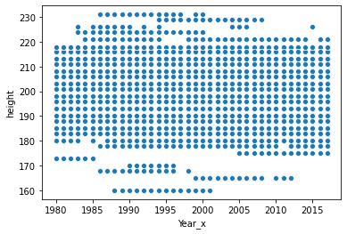

```python
# Plot Year vs height
r = sns.scatterplot(x='Year_x', y='height', data=df)
```

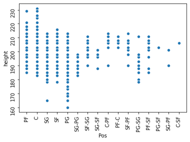

```python
# Plot Position vs height
r = sns.scatterplot(x='Pos', y='height', data=df)
r.tick_params(labelsize = 10,rotation=90)
```

```python
# Clean up the number of position to the original 5
df['Pos'] = df['Pos'].str.split('-').str[0]
```

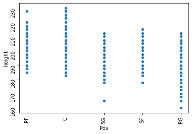

```python
# Plot position vs height
r = sns.scatterplot(x='Pos', y='height', data=df)
r.tick_params(labelsize = 10,rotation=90)
```

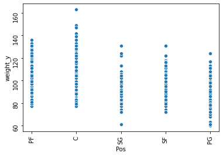

```python
# Plot position vs weight
r = sns.scatterplot(x='Pos', y='weight_y', data=df)
r.tick_params(labelsize = 10,rotation=90)
```

We can clearly see a relationship between height and position and weight and position, meaning every position has a certain profile which can lead us to discover if each position has a different playing style.

```python
# Find the average height for every year, position and then fill the null values
df.height = df.groupby(['Year_x','Pos'])['height'].apply(lambda x: x.fillna(x.mean()))
df.height = df.height.fillna(df.height.mean())
```

```python
# Find the average weight for every year, position and then fill the null values
df.weight_y = df.groupby(['Year_x','Pos'])['weight_y'].apply(lambda x: x.fillna(x.mean()))
df.weight_y = df.weight_y.fillna(df.weight_y.mean())
```

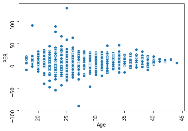

```python
# Lets look at Age, plot Age vs PER (player efficiency rating)
r = sns.scatterplot(x='Age', y='PER', data=df)
r.tick_params(labelsize = 10,rotation=90)
```

```python
# Find the average for the metrics and then fill the null values

df.GS = df.groupby(['Year_x','Pos','Age'])['GS'].apply(lambda x: x.fillna(x.mean()))
df.GS = df.GS.fillna(df.GS.mean()).round()

df.PER = df.groupby(['Year_x','Pos','Age'])['PER'].apply(lambda x: x.fillna(x.mean()))
df.PER = df.PER.fillna(df.PER.mean())

df["3PAr"] = df.groupby(['Year_x','Pos'])['3PAr'].apply(lambda x: x.fillna(x.mean()))
df["3PAr"] = df["3PAr"].fillna(df["3PAr"].mean())

df["FTr"] = df.groupby(['Year_x','Pos'])['FTr'].apply(lambda x: x.fillna(x.mean()))
df["FTr"] = df["FTr"].fillna(df["FTr"].mean())

df["ORB%"] = df.groupby(['Year_x','Pos'])['ORB%'].apply(lambda x: x.fillna(x.mean()))
df["ORB%"] = df["ORB%"].fillna(df["ORB%"].mean())

df["DRB%"] = df.groupby(['Year_x','Pos'])['DRB%'].apply(lambda x: x.fillna(x.mean()))
df["DRB%"] = df["DRB%"].fillna(df["DRB%"].mean())

df["TRB%"] = df.groupby(['Year_x','Pos'])['TRB%'].apply(lambda x: x.fillna(x.mean()))
df["TRB%"] = df["TRB%"].fillna(df["TRB%"].mean())

df["STL%"] = df.groupby(['Year_x','Pos'])['STL%'].apply(lambda x: x.fillna(x.mean()))
df["STL%"] = df["STL%"].fillna(df["STL%"].mean())

df["BLK%"] = df.groupby(['Year_x','Pos'])['BLK%'].apply(lambda x: x.fillna(x.mean()))
df["BLK%"] = df["BLK%"].fillna(df["BLK%"].mean())

df["AST%"] = df.groupby(['Year_x','Pos'])['AST%'].apply(lambda x: x.fillna(x.mean()))
df["AST%"] = df["AST%"].fillna(df["AST%"].mean())

df["TOV%"] = df.groupby(['Year_x','Pos'])['TOV%'].apply(lambda x: x.fillna(x.mean()))
df["TOV%"] = df["TOV%"].fillna(df["TOV%"].mean())

df["USG%"] = df.groupby(['Year_x','Pos'])['USG%'].apply(lambda x: x.fillna(x.mean()))
df["USG%"] = df["USG%"].fillna(df["USG%"].mean())
```

```python
df.isna().sum()
```

```
Year_x           0
Player           0
Pos              0
Age              0
abbs             0
G                0
GS               0
MP               0
PER              0
TS%             38
3PAr             0
FTr              0
ORB%             0
DRB%             0
TRB%             0
AST%             0
STL%             0
BLK%             0
TOV%             0
USG%             0
OWS              0
DWS              0
WS               0
WS/48            3
OBPM             0
DBPM             0
BPM              0
VORP             0
FG               0
FGA              0
FG%             45
3P               0
3PA              0
3P%           2619
2P               0
2PA              0
2P%             62
eFG%            45
FT               0
FTA              0
FT%            430
ORB              0
DRB              0
TRB              0
AST              0
STL              0
BLK              0
TOV              0
PF               0
PTS              0
team_name        0
mvp              0
final_won        0
final_lost       0
college          0
height           0
weight_y         0
Year_y           0
experience       0
dtype: int64
```

```python
# Checking metric TS% to see null values
nullchecker = df[(df["TS%"].isnull())]
nullchecker.head()
```

|  | Year_x | Player | Pos | Age | abbs | G | GS | MP | PER | TS% | ... | PTS | team_name | mvp | final_won | final_lost | college | height | weight_y | Year_y | experience |
| --- | --- | --- | --- | --- | --- | --- | --- | --- | --- | --- | --- | --- | --- | --- | --- | --- | --- | --- | --- | --- | --- |
| 1716 | 1996.0 | Tim Kempton | PF | 32.0 | ATL | 3.0 | 0.0 | 11.0 | -6.2 | NaN | ... | 0.0 | Atlanta Hawks | 0 | 0.0 | 0.0 | University of Notre Dame | 208.0 | 111.0 | 1987.0 | 9.0 |
| 2043 | 2001.0 | Andy Panko | SF | 23.0 | ATL | 1.0 | 0.0 | 1.0 | 0.0 | NaN | ... | 0.0 | Atlanta Hawks | 0 | 0.0 | 0.0 | Lebanon Valley College | 206.0 | 100.0 | 2001.0 | 0.0 |
| 2097 | 2002.0 | Dickey Simpkins | PF | 29.0 | ATL | 1.0 | 0.0 | 3.0 | 11.6 | NaN | ... | 0.0 | Atlanta Hawks | 0 | 0.0 | 0.0 | Providence College | 206.0 | 112.0 | 1995.0 | 7.0 |
| 4043 | 2014.0 | Chris Smith | PG | 26.0 | NYK | 2.0 | 0.0 | 2.0 | 0.0 | NaN | ... | 0.0 | New York Knicks | 0 | 0.0 | 0.0 | University of Connecticut | 208.0 | 104.0 | 1993.0 | 21.0 |
| 4044 | 2014.0 | Chris Smith | PG | 26.0 | NYK | 2.0 | 0.0 | 2.0 | 0.0 | NaN | ... | 0.0 | New York Knicks | 0 | 0.0 | 0.0 | University of Louisville | 208.0 | 104.0 | 1993.0 | 21.0 |

5 rows × 59 columns

TSA = FGA + 0.44 * FTA

(True Shooting) = (Field Goal Attempts) + 0.44 * (Free Throw Attempts)

TS% = PTS / (2 * TSA)

True Shooting Percentage = Points / 2 * (True Shooting)

Any of the variables where a percentge is calculated and is giving a null is due to the denominator of the calculation being 0. As a result these metrics will be replaced with 0. Like the example formula above.

```python
# Converting null values
df['TS%'] = df['TS%'].replace(np.nan,0)
df['WS/48'] = df['WS/48'].replace(np.nan,0)
df['FG%'] = df['FG%'].replace(np.nan,0)
df['3P%'] = df['3P%'].replace(np.nan,0)
df['FT%'] = df['FT%'].replace(np.nan,0)
df['eFG%'] = df['eFG%'].replace(np.nan,0)
df['2P%'] = df['2P%'].replace(np.nan,0)
df['3P%'] = df['3P%'].replace(np.nan,0)
```

```python
df.isna().sum()
```

```
Year_x        0
Player        0
Pos           0
Age           0
abbs          0
G             0
GS            0
MP            0
PER           0
TS%           0
3PAr          0
FTr           0
ORB%          0
DRB%          0
TRB%          0
AST%          0
STL%          0
BLK%          0
TOV%          0
USG%          0
OWS           0
DWS           0
WS            0
WS/48         0
OBPM          0
DBPM          0
BPM           0
VORP          0
FG            0
FGA           0
FG%           0
3P            0
3PA           0
3P%           0
2P            0
2PA           0
2P%           0
eFG%          0
FT            0
FTA           0
FT%           0
ORB           0
DRB           0
TRB           0
AST           0
STL           0
BLK           0
TOV           0
PF            0
PTS           0
team_name     0
mvp           0
final_won     0
final_lost    0
college       0
height        0
weight_y      0
Year_y        0
experience    0
dtype: int64
```

```python
df.head()
```

|  | Year_x | Player | Pos | Age | abbs | G | GS | MP | PER | TS% | ... | PTS | team_name | mvp | final_won | final_lost | college | height | weight_y | Year_y | experience |
| --- | --- | --- | --- | --- | --- | --- | --- | --- | --- | --- | --- | --- | --- | --- | --- | --- | --- | --- | --- | --- | --- |
| 973 | 1980.0 | Tim Bassett | PF | 28.0 | ATL | 12.0 | 27.0 | 164.0 | 6.7 | 0.419 | ... | 34.0 | Atlanta Hawks | 0 | 0.0 | 0.0 | University of Georgia | 203.0 | 102.0 | 1977.0 | 3.0 |
| 974 | 1980.0 | Kent Benson | C | 25.0 | ATL | 73.0 | 27.0 | 1891.0 | 13.1 | 0.513 | ... | 698.0 | Atlanta Hawks | 0 | 0.0 | 0.0 | Indiana University | 208.0 | 106.0 | 1978.0 | 2.0 |
| 975 | 1980.0 | Ron Boone | SG | 33.0 | ATL | 81.0 | 0.0 | 2392.0 | 12.1 | 0.501 | ... | 1004.0 | Atlanta Hawks | 0 | 0.0 | 0.0 | Idaho State University | 188.0 | 90.0 | 1977.0 | 3.0 |
| 976 | 1980.0 | Tom Boswell | PF | 26.0 | ATL | 79.0 | 0.0 | 2077.0 | 14.3 | 0.616 | ... | 903.0 | Atlanta Hawks | 0 | 0.0 | 0.0 | University of South Carolina | 206.0 | 99.0 | 1976.0 | 4.0 |
| 977 | 1980.0 | John Brown | SF | 28.0 | ATL | 32.0 | 27.0 | 385.0 | 5.1 | 0.444 | ... | 112.0 | Atlanta Hawks | 0 | 0.0 | 0.0 | University of Missouri | 201.0 | 99.0 | 1974.0 | 6.0 |

5 rows × 59 columns

### Feature Engineering:

For the first feature I created a calculated a column which highlights the first year an NBA player starts in the league. The idea behind this is I could then take away the debut year from the current year and this would give me years of experience in the NBA. Which could be a useful insight into the experience of an MVP player and a Championship winning team.

The next features are going to be more about the effect a player has when on the court. Most of our variables are totals and do not reflect the true performance of a player time on the court. A result will be creating new features which will be per game.

```python
# Offensive Rebounds
df['ORB_per'] = (df['ORB'] / df['G']).round()
# Defensive Rebounds
df['DRB_per'] = (df['DRB'] / df['G']).round()
# Total Rebounds
df['TRB_per'] = (df['TRB'] / df['G']).round()
# Assists
df['AST_per'] = (df['AST'] / df['G']).round()
# Steals
df['STL_per'] = (df['STL'] / df['G']).round()
# Blocks
df['BLK_per'] = (df['BLK'] / df['G']).round()
# Turnovers
df['TOV_per'] = (df['TOV'] / df['G']).round()
# Personal Fouls
df['PF_per'] = (df['PF'] / df['G']).round()
# Points
df['PTS_per'] = (df['PTS'] / df['G']).round()
# Field Goals
df['FG_per'] = (df['FG'] / df['G']).round()
# 3 points
df['3P_per'] = (df['3P'] / df['G']).round()
# 3 points attempted
df['3PA_per'] = (df['3PA'] / df['G']).round()
# 2 points
df['2P_per'] = (df['2P'] / df['G']).round()
# 2 points attempted
df['2PA_per'] = (df['2PA'] / df['G']).round()
# Free Throws
df['FT_per'] = (df['FT'] / df['G']).round()
# Free Throws Attempted
df['FTA_per'] = (df['FTA'] / df['G']).round()
```

```python
# Removing useless stats and metrics
df=df.drop(['FTr','AST%','STL%','BLK%','TOV%','USG%','OWS','DWS','WS/48',
            'OBPM','DBPM','3P%','2P%','eFG%'], axis=1)
```

```python
df.head()
```

|  | Year_x | Player | Pos | Age | abbs | G | GS | MP | PER | TS% | ... | TOV_per | PF_per | PTS_per | FG_per | 3P_per | 3PA_per | 2P_per | 2PA_per | FT_per | FTA_per |
| --- | --- | --- | --- | --- | --- | --- | --- | --- | --- | --- | --- | --- | --- | --- | --- | --- | --- | --- | --- | --- | --- |
| 973 | 1980.0 | Tim Bassett | PF | 28.0 | ATL | 12.0 | 27.0 | 164.0 | 6.7 | 0.419 | ... | 1.0 | 2.0 | 3.0 | 1.0 | 0.0 | 0.0 | 1.0 | 3.0 | 1.0 | 1.0 |
| 974 | 1980.0 | Kent Benson | C | 25.0 | ATL | 73.0 | 27.0 | 1891.0 | 13.1 | 0.513 | ... | 2.0 | 3.0 | 10.0 | 4.0 | 0.0 | 0.0 | 4.0 | 8.0 | 1.0 | 2.0 |
| 975 | 1980.0 | Ron Boone | SG | 33.0 | ATL | 81.0 | 0.0 | 2392.0 | 12.1 | 0.501 | ... | 2.0 | 3.0 | 12.0 | 5.0 | 0.0 | 1.0 | 5.0 | 11.0 | 2.0 | 2.0 |
| 976 | 1980.0 | Tom Boswell | PF | 26.0 | ATL | 79.0 | 0.0 | 2077.0 | 14.3 | 0.616 | ... | 2.0 | 3.0 | 11.0 | 4.0 | 0.0 | 0.0 | 4.0 | 8.0 | 3.0 | 3.0 |
| 977 | 1980.0 | John Brown | SF | 28.0 | ATL | 32.0 | 27.0 | 385.0 | 5.1 | 0.444 | ... | 1.0 | 2.0 | 4.0 | 1.0 | 0.0 | 0.0 | 1.0 | 3.0 | 1.0 | 2.0 |

5 rows × 61 columns

### MVP and Championships

Let’s understand the impact an MVP player has on becoming a champion, this means the team wins the NBA championship.

```python
# Filter dataframe for MVP winners only
mvp_df = df[df.mvp == 1]
# Group by Pos to calculate the average height and weight
mvp_champ = mvp_df.groupby(['Player'], as_index=False, sort=False)[["final_won",
                                                              "final_lost"
                                                             ]].sum()
mvp_champ['percent'] = (mvp_champ['final_won'] / (mvp_champ['final_won']+mvp_champ['final_lost']))*100
mvp_champ['percent'] = mvp_champ['percent'].round()
# Sort the group by table
mvp_champ = mvp_champ.sort_values(by=['percent','final_won'], ascending=False)
mvp_champ.head(100)
```

|  | Player | final_won | final_lost | percent |
| --- | --- | --- | --- | --- |
| 9 | Michael Jordan | 4.0 | 0.0 | 100.0 |
| 16 | LeBron James | 2.0 | 0.0 | 100.0 |
| 1 | Kareem Abdul-Jabbar | 1.0 | 0.0 | 100.0 |
| 3 | Shaquille O'Neal | 1.0 | 0.0 | 100.0 |
| 6 | Moses Malone | 1.0 | 0.0 | 100.0 |
| 11 | Hakeem Olajuwon | 1.0 | 0.0 | 100.0 |
| 19 | Tim Duncan | 1.0 | 0.0 | 100.0 |
| 8 | Larry Bird | 2.0 | 1.0 | 67.0 |
| 0 | Stephen Curry | 1.0 | 1.0 | 50.0 |
| 2 | Magic Johnson | 1.0 | 1.0 | 50.0 |
| 4 | Kobe Bryant | 0.0 | 1.0 | 0.0 |
| 7 | Allen Iverson | 0.0 | 1.0 | 0.0 |
| 14 | Charles Barkley | 0.0 | 1.0 | 0.0 |
| 17 | Karl Malone | 0.0 | 1.0 | 0.0 |
| 5 | Julius Erving | 0.0 | 0.0 | NaN |
| 10 | Derrick Rose | 0.0 | 0.0 | NaN |
| 12 | Kevin Durant | 0.0 | 0.0 | NaN |
| 13 | Russell Westbrook | 0.0 | 0.0 | NaN |
| 15 | Steve Nash | 0.0 | 0.0 | NaN |
| 18 | David Robinson | 0.0 | 0.0 | NaN |
| 20 | Dirk Nowitzki | 0.0 | 0.0 | NaN |
| 21 | Kevin Garnett | 0.0 | 0.0 | NaN |

From the 1980 season till 2017 we have had:

- 22 different MVPs
- Only 8 MVPs never reached a final
- 7 MVPs have reached the final and lost, 4 of which have a 100% loss record and 3 have a win percentage ranging from 50% to 67%
- 10 MVPs have reached the final and won, 7 of which have a 100%-win record
- Most wins in a final is 4 by Michael Jordan at 100% win rate

From our sample dataset we can workout the probability of being a champion given MVP award has been won.

So after using a group by functions and exporting the data I used excel to calculate the below:

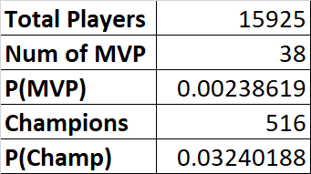

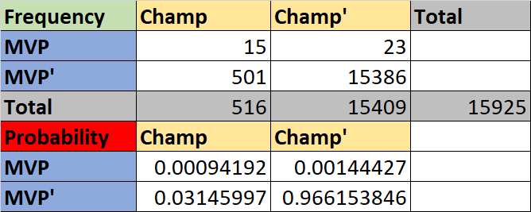

### Bayes Theorm:

P(Champ|MVP) = P(MVP|CHAMP) * P(CHAMP) / P(MVP)

```
         = P(MVP|CHAMP) * (0.03240188) / (0.00238619)
```

P(MVP|CHAMP) is unknown so we can use conditional probability to calculate it using the joint probability:

P(MVP|CHAMP) = P(MVP,CHAMP) / P(CHAMP)

```
         = (0.00094192) / (0.03240188)

         = 0.0290699
```

Now we can replace back into the first formula:

P(Champ|MVP) = (0.0290699) * (0.03240188) / (0.00238619) = 0.39

So, The probability of a Player being a champion given he has won the MVP award is around 40%

### What it takes to be a an MVP?

Now lets take a look at what makes an MVP player

```python
# Filter dataframe for MVP winners only
mvp_df = df[df.mvp == 1]
# Gather basic information about the dataset
print(f"Rows: {mvp_df.shape[0]}\nColumns: {mvp_df.shape[1]}")
```

```
Rows: 38
Columns: 61
```

```python
# Filter dataframe for non MVP winners only
non_mvp_df = df[df.mvp == 0]
# Gather basic information about the dataset
print(f"Rows: {non_mvp_df.shape[0]}\nColumns: {non_mvp_df.shape[1]}")
```

```
Rows: 15887
Columns: 61
```

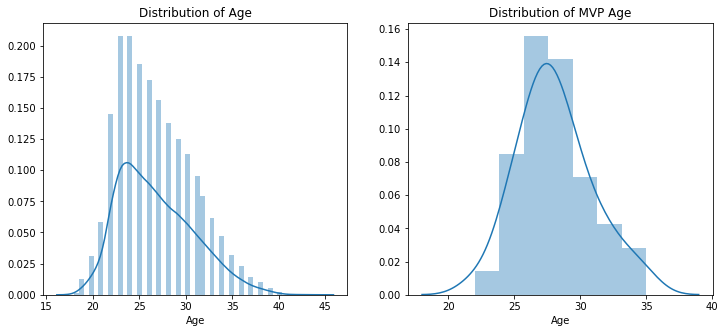

```python
# Distribution of Age in the NBA
plt.figure(figsize=(12,5))
plt.subplot(1,2,1)
sns.distplot(non_mvp_df.Age)
plt.title('Distribution of Age');
# Distribution of MVP Age in the NBA
plt.subplot(1,2,2)
sns.distplot(mvp_df.Age)
plt.title('Distribution of MVP Age');
```

The distribution of Age in the NBA is skewed slightly peaking at 23 & 24 years of age in comparison to MVP age which peaks at 26-30 years of age. Overall, it a nice funnel-like shape which suggests that the homoscedasticity assumption. Given that we will be using Logistic Regression a normal distribution is not required as an assumption unlike linear regression.

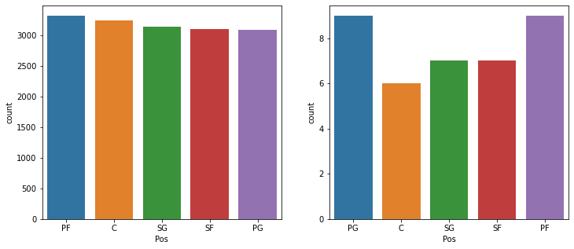

```python
# Count of Position in the NBA
plt.figure(figsize=(12,5))
plt.subplot(1,2,1)
sns.countplot(x='Pos',data=non_mvp_df)
plt.subplot(1,2,2)
# Count of MVP Position in the NBA
sns.countplot(x='Pos',data=mvp_df)
plt.show()
```

In terms of position I don’t see a significant difference in the count for each position, In terms of positions of MVP winners there is a slight difference but when you consider its over 38 year period the difference between the highest and lowest is 3 counts, so in my eyes not so significant.

```python
# Create a samller dataframe to melt for boxplot for non mvps
melt_non1 = non_mvp_df[['Age','G','GS','experience']]
# Melt dataframe
melt_non1 = pd.melt(melt_non1)
# Create a samller dataframe to melt for boxplot for mvps
melt_mvp1 = mvp_df[['Age','G','GS','experience']]
# Melt dataframe
melt_mvp1 = pd.melt(melt_mvp1)
```

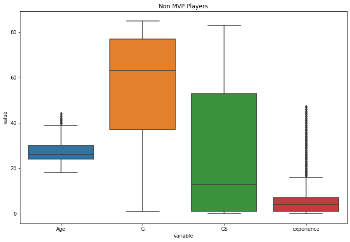

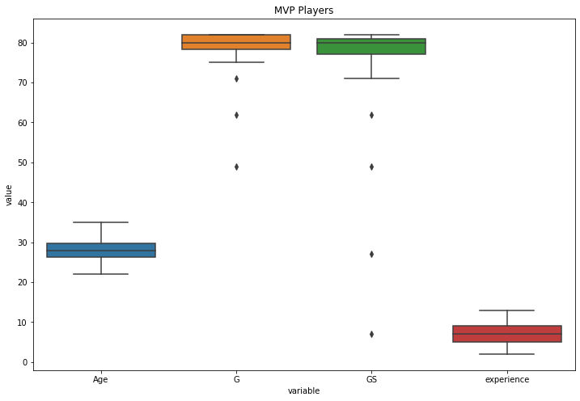

```python
# Boxplot for non mvps
plt.figure(figsize=(12,8))
sns.boxplot(x='variable',y ='value',data=melt_non1)
plt.title("Non MVP Players")
# Boxplot for mvps
plt.figure(figsize=(12,8))
sns.boxplot(x='variable',y ='value',data=melt_mvp1)
plt.title("MVP Players")
plt.show()
```

```python
# Group by variable to calculate the average
mvp_avg1 = melt_mvp1.groupby(['variable'],
                             as_index=False, sort=False)[["value"]].mean()
non_mvp_avg1 = melt_non1.groupby(['variable'],
                                 as_index=False,
                                 sort=False)[["value"]].mean()
```

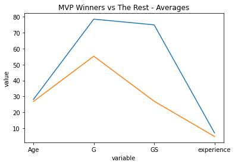

```python
# Plot the average line
fig = plt.figure()
for frame in [mvp_avg1, non_mvp_avg1]:
    sns.lineplot(x = frame['variable'],y = frame['value'])
plt.title('MVP Winners vs The Rest - Averages')
plt.show()
```

Looking at the Box plots above we can see a big difference in “G”- games played and “GS” – Games Started between MVP players and the rest. MVP players start and play nearly every game while the range of the rest of the players can range from 0. There isn’t significant difference between age and experience. This is clearly visualised in the average line plot.

```python
# Lets do the same for the stats for MVP and the rest
melt_non = non_mvp_df[['ORB_per','DRB_per','TRB_per','AST_per',
                       'STL_per','BLK_per','TOV_per','PF_per','PTS_per']]
melt_non = pd.melt(melt_non)
melt_mvp = mvp_df[['ORB_per','DRB_per','TRB_per',
                   'AST_per','STL_per','BLK_per','TOV_per','PF_per',
                   'PTS_per']]
melt_mvp = pd.melt(melt_mvp)
```

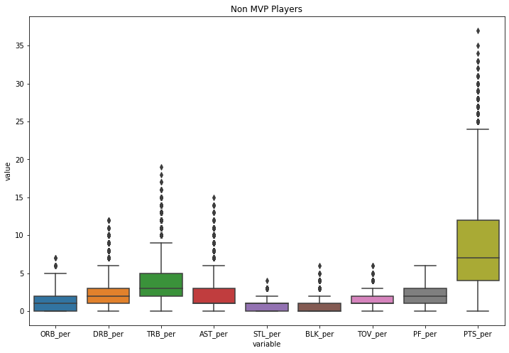

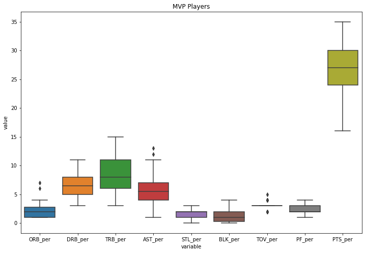

```python
# Plot boxplots for the melted stats dataframe
plt.figure(figsize=(12,8))
sns.boxplot(x='variable',y ='value',data=melt_non)
plt.title("Non MVP Players")

plt.figure(figsize=(12,8))
sns.boxplot(x='variable',y ='value',data=melt_mvp)
plt.title("MVP Players")

plt.show()
```

```python
# Group by variable to calculate the average
mvp_avg = melt_mvp.groupby(['variable'], as_index=False,
                           sort=False)[["value"]].mean()
non_mvp_avg = melt_non.groupby(['variable'],
                               as_index=False, sort=False)[["value"]].mean()
```

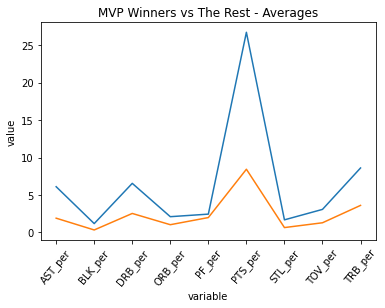

```python
# Plot averages for both MVP and the rest
fig = plt.figure()
for frame in [mvp_avg, non_mvp_avg]:
    sns.lineplot(x = frame['variable'],y = frame['value'])
plt.xticks(rotation=50)
plt.title('MVP Winners vs The Rest - Averages')
plt.show()
```

Looking at the Box plots and average line plot above we can see on average the MVP is better across the board. The biggest difference is in “PTS_per”- Points per game in comparison to any other change from the rest of the players. Other noticeable increases are “AST_per” – Assists per game, “DRB_per” – Defensive rebounds and “TRB_per” – Total rebounds.

Now lets look at how positions impact the playing style of the MVP

```python
# import package
from IPython.display import Image
# from (https://en.wikipedia.org/wiki/Basketball_positions)
Image(filename='Basketball_Positions.png')
```

[output not shown]

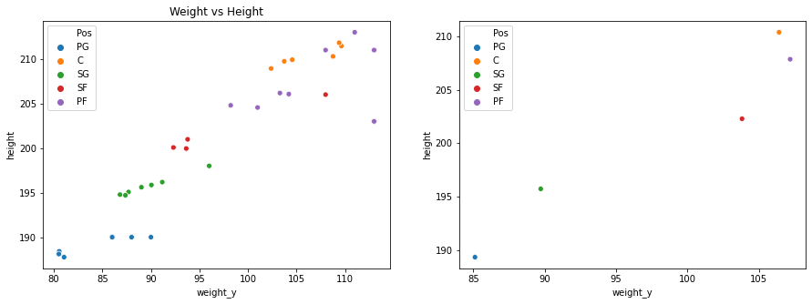

```python
# Group by Pos to calculate the average height and weight
pos_hw = mvp_df.groupby(['Pos'], as_index=False, sort=False)[["height",
                                                              "weight_y"
                                                             ]].mean()
# Plot height vs weight and repeat for the average
plt.figure(figsize=(15,5))
plt.subplot(1,2,1)
sns.scatterplot(x="weight_y",y="height",data=mvp_df,hue="Pos")
plt.title("Weight vs Height")
plt.subplot(1,2,2)
sns.scatterplot(x="weight_y",y="height",data=pos_hw,hue="Pos")
plt.show()
```

```python
# view group by table
round(pos_hw)
```

|  | Pos | height | weight_y |
| --- | --- | --- | --- |
| 0 | PG | 189.0 | 85.0 |
| 1 | C | 210.0 | 106.0 |
| 2 | SG | 196.0 | 90.0 |
| 3 | SF | 202.0 | 104.0 |
| 4 | PF | 208.0 | 107.0 |

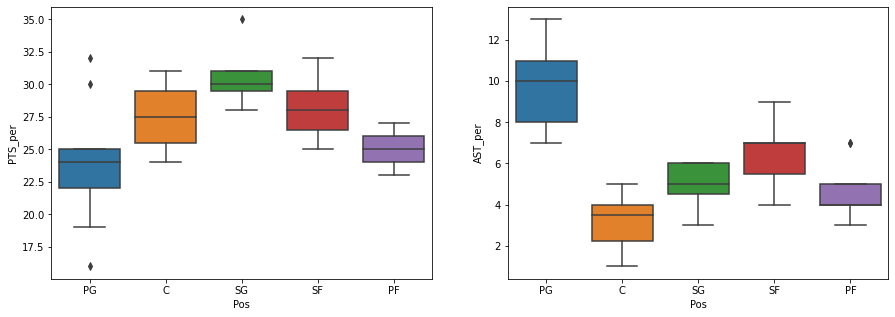

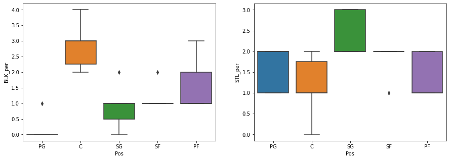

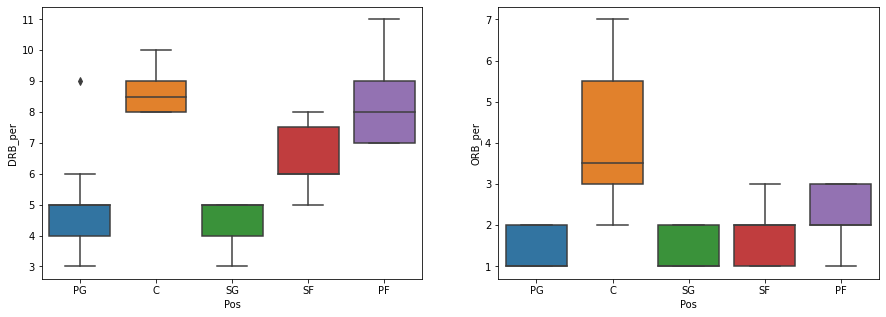

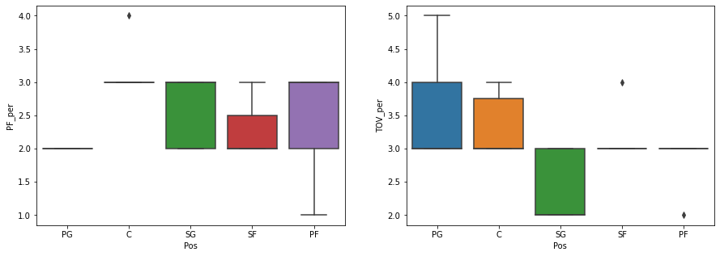

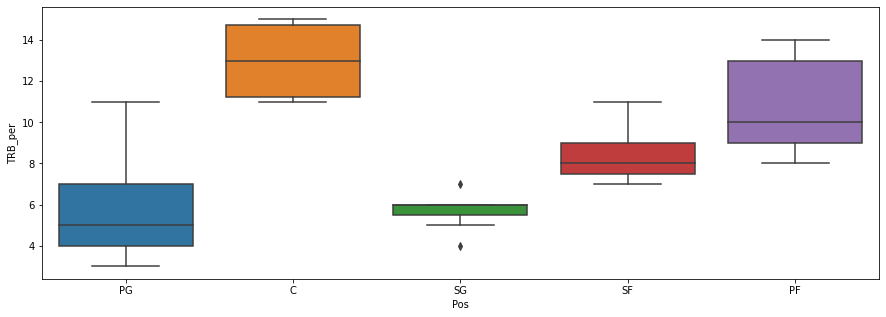

```python
# Box plot of stats for different positions

plt.figure(figsize=(15,5))
plt.subplot(1,2,1)
sns.boxplot(y='PTS_per', x ='Pos', data = mvp_df)

plt.subplot(1,2,2)
sns.boxplot(y='AST_per', x ='Pos', data = mvp_df)
plt.show()

plt.figure(figsize=(15,5))
plt.subplot(1,2,1)
sns.boxplot(y='BLK_per', x ='Pos', data = mvp_df)

plt.subplot(1,2,2)
sns.boxplot(y='STL_per', x ='Pos', data = mvp_df)
plt.show()

plt.figure(figsize=(15,5))
plt.subplot(1,2,1)
sns.boxplot(y='DRB_per', x ='Pos', data = mvp_df)

plt.subplot(1,2,2)
sns.boxplot(y='ORB_per', x ='Pos', data = mvp_df)
plt.show()

plt.figure(figsize=(15,5))
plt.subplot(1,2,1)
sns.boxplot(y='PF_per', x ='Pos', data = mvp_df)

plt.subplot(1,2,2)
sns.boxplot(y='TOV_per', x ='Pos', data = mvp_df)
plt.show()
plt.figure(figsize=(15,5))
sns.boxplot(y='TRB_per', x ='Pos', data = mvp_df)
plt.show()
```

#### Position Profiles

Based on analysis

“PG” – Point Guard

- Shorter and lighter than all other positions with an average height of 189cm and weight of 85kg
- AST - King of assists
- STL – I can steal the ball if I must
- TOV – I can turn things around
- PF – I dont like to foul
- Known as "The cool one"

“SG” – Shooting Guard

- This group of players are taller than PGs but not necessarily always heavier with an average height of 196cm and weight of 90kg
- PTS – I can’t miss
- STL – I can steal the ball alright
- Known as "The Talisman"

“SF” – Small Forward

- Is the third tallest group of players with an average height of 202cm and weight of 104kg. due to an outlier in the MVP data in weight the average looks more in the middle of the range 90-95kg
- PTS - I can shoot to
- AST – I can assist to
- STL – I can steal the ball to
- Known as "The main man"

“PF” – Power Forward

- Unlike the SF the Power forwards are the heaviest group of players and some of the tallest in NBA with an average height of 208cm and weight of 107kg
- BLK – I can block
- DRB – I can defend a rebound
- Known as "The defender"

“C” – Center

- These group of players are the tallest in the Nba with an average height of 210cm and weight of 106kg
- PTS – I can score to
- BLK – The blocking King
- DRB – Big on defensive rebounds
- ORB – Offensive rebound, all mine!
- PF – I play dirty
- TOV – I can turn things around
- Known as "The beast"

### Clustering MVP Playing Style

From the analysis above we can see that positions have different playing styles and they are dependent on your height and weight along with your ability. We will cluster solely on ability to see how the algorithm groups the MVPs.

```python
# First create a dataframe with the columns we require
mvp_clust = mvp_df[['Pos','ORB_per','DRB_per','TRB_per','AST_per',
                    'STL_per','BLK_per','TOV_per','PF_per','PTS_per']]
mvp_clust.head()
```

|  | Pos | ORB_per | DRB_per | TRB_per | AST_per | STL_per | BLK_per | TOV_per | PF_per | PTS_per |
| --- | --- | --- | --- | --- | --- | --- | --- | --- | --- | --- |
| 4941 | PG | 1.0 | 4.0 | 4.0 | 8.0 | 2.0 | 0.0 | 3.0 | 2.0 | 24.0 |
| 4958 | PG | 1.0 | 5.0 | 5.0 | 7.0 | 2.0 | 0.0 | 3.0 | 2.0 | 30.0 |
| 6983 | C | 2.0 | 8.0 | 11.0 | 5.0 | 1.0 | 3.0 | 4.0 | 3.0 | 25.0 |
| 7077 | PG | 2.0 | 5.0 | 6.0 | 12.0 | 2.0 | 0.0 | 4.0 | 2.0 | 24.0 |
| 7102 | PG | 1.0 | 6.0 | 8.0 | 13.0 | 2.0 | 0.0 | 4.0 | 2.0 | 22.0 |

```python
# Converting null values
mvp_clust['Pos'] = mvp_clust['Pos'].replace('PG',0)
mvp_clust['Pos'] = mvp_clust['Pos'].replace('SG',1)
mvp_clust['Pos'] = mvp_clust['Pos'].replace('SF',2)
mvp_clust['Pos'] = mvp_clust['Pos'].replace('PF',3)
mvp_clust['Pos'] = mvp_clust['Pos'].replace('C',4)
```

```python
# Select columns
cols_to_norm = ['ORB_per','DRB_per','TRB_per','AST_per','STL_per','BLK_per','TOV_per','PF_per','PTS_per']

# Import library
from sklearn.preprocessing import StandardScaler
from sklearn import preprocessing
# Scale the metrics since clustering is distance based
min_max_scaler = preprocessing.MinMaxScaler()
mvp_clust[cols_to_norm]= min_max_scaler.fit_transform(mvp_clust[cols_to_norm])
```

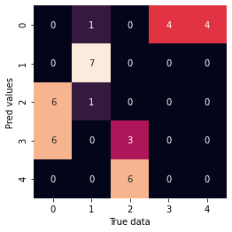

```python
# Separate features and labels
features = mvp_clust.iloc[:,1:]
knownLabels = mvp_clust.iloc[:,0]

# Import Library
from sklearn.cluster import KMeans
#computing K-Means with K = 5
kmeansModel = KMeans(n_clusters=5)
kmeansModel.fit_predict(features)
clusterLabels = kmeansModel.labels_

# Check if labels matach
comp = clusterLabels == knownLabels
comp.value_counts()

# Import Library
from sklearn.metrics import confusion_matrix
# Display results in confusion matrix
mat = confusion_matrix(knownLabels,clusterLabels)
sns.heatmap(mat, square = True, annot = True, fmt = 'd', cbar = False)
plt.xlabel('True data')
plt.ylabel('Pred values')
plt.show()
```

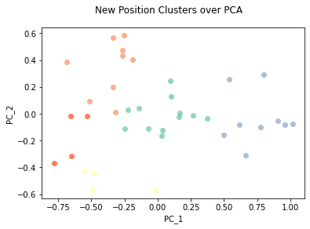

```python
# Import Library
from sklearn.decomposition import PCA
# Set PCA compnenet number
pca = PCA(n_components=2)
#fit a PCA model to the data
pca.fit(features)
projectedAxes = pca.transform(features)
# Create dataframe so easier to filter
projectedAxes=pd.DataFrame(projectedAxes)

# Reset index for dataframes
mvp_clust.reset_index(drop=True, inplace=True)
projectedAxes.reset_index(drop=True, inplace=True)
# Concate to help with comparing
conData = pd.concat( [mvp_clust, projectedAxes], axis=1)
# Isolate known labels with reset index
knownLabels2=conData.iloc[:,0]

plt.figure(1)
plt.suptitle('New Position Clusters over PCA')
plt.xlabel('PC_1')
plt.ylabel('PC_2')
# Scatterplots on top of each other for each cluster
plt.scatter(projectedAxes[clusterLabels==0][0], projectedAxes[clusterLabels==0][1], c = "#66c2a5", s = 50, alpha = 0.7, linewidth=0) # greenish
plt.scatter(projectedAxes[clusterLabels==1][0], projectedAxes[clusterLabels==1][1], c = "#fc8d62", s = 50, alpha = 0.7, linewidth=0) # orangish
plt.scatter(projectedAxes[clusterLabels==2][0], projectedAxes[clusterLabels==2][1], c = "#8da0cb", s = 50, alpha = 0.7, linewidth=0) # blueish
plt.scatter(projectedAxes[clusterLabels==3][0], projectedAxes[clusterLabels==3][1], c = "#ffff99", s = 50, alpha = 0.7, linewidth=0) # yellow
plt.scatter(projectedAxes[clusterLabels==4][0], projectedAxes[clusterLabels==4][1], c = "#ff471a", s = 50, alpha = 0.7, linewidth=0) # red

plt.show()
```

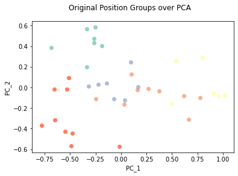

```python
plt.figure(2)
plt.suptitle('Original Position Groups over PCA')
plt.xlabel('PC_1')
plt.ylabel('PC_2')
# Scatterplots on top of each other for each Position
plt.scatter(projectedAxes[knownLabels2==0][0], projectedAxes[knownLabels2==0][1], c = "#ff471a", s = 50, alpha = 0.7, linewidth=0) # red
plt.scatter(projectedAxes[knownLabels2==1][0], projectedAxes[knownLabels2==1][1], c = "#66c2a5", s = 50, alpha = 0.7, linewidth=0) # green
plt.scatter(projectedAxes[knownLabels2==2][0], projectedAxes[knownLabels2==2][1], c = "#8da0cb", s = 50, alpha = 0.7, linewidth=0) # blueish
plt.scatter(projectedAxes[knownLabels2==3][0], projectedAxes[knownLabels2==3][1], c = "#fc8d62", s = 50, alpha = 0.7, linewidth=0) # orange
plt.scatter(projectedAxes[knownLabels2==4][0], projectedAxes[knownLabels2==4][1], c = "#ffff99", s = 50, alpha = 0.7, linewidth=0) # yellow
plt.show()
```

From the scatter plots above we can see the original MVP positions overlap but with the new clusters there is a clear separation. Let’s analyse this further to understand the changes.